# Appendix B: Data manipulation, RoB visualization, and PRIMED workflow

Author

Mikkel H. Vembye

Published

July 7, 2026

# Introduction

This document contains data manipulation, risk of bias visualizations and the preliminary data analysis for the meta-analyses with dependent effects (PRIMED) in Dalgaard et al. (2026). As we conduct separate analyses for reintegration (primary analysis) and mental health (secondary analysis) outcomes, we have divided the tabulation and visualization according to the two types of effect size estimates. In most cases, the main presentation of reintegration outcome data appears in the center column of the document, while the presentation of the mental health outcome data is shown in the right column. Where larger tables or visualizations are required, we have used tabsets to distinguish between reintegration and mental health analyses. To view the mental health presentation, select the ‘Mental health’ tab. In a few instances, reintegration and mental health outcomes are tabulated and visualized together to provide an overall view of the relationships between these two types of estimates. All packages that we have used to create this document, can be found in the next section.

Dalgaard, Nina T, Jakob K Jensen, Jasmin S Adada, et al. 2026. *A Meta-Analysis of the Effects of Group-Based Interventions on Social Reintegration of Marginalized Adults with Mental Illness*. Open Science Framework.

## R packages

Below, we present the R package we use in this document. For exact R package versions, see the Session Information at the bottom of this document.

```r
# Load packages -----------------------------------------------------------
library(knitr)
library(kableExtra)
library(skimr)
library(janitor)
library(tidyverse)
library(tidyr)
library(metafor)
library(clubSandwich)
library(fastDummies)
library(ggrepel)
library(ggExtra)
library(ggridges)
library(MetBrewer)
library(GGally)
library(igraph)
library(fastDummies)
library(patchwork)
library(ggh4x)
library(writexl)
```

# Data manipulation - prepare data sets

In the following section, we create all the variables that are used in the main analyses of the review. Unfold the below code to see this exact manipulations.

## Loading data

```r
# Loading the needed data for analysis
group_based_dat <- readRDS("Group-based interventions data.RDS") |>
  # The post-measurement of Empowerment Scale seems flawed for the study by
  # Barbic et al. 2009 we therefore we exclude it from the analysis
  filter(!(authors == "Barbic et al." & test_name == "The Empowerment Scale")) |>
  mutate(
    author_year = paste(authors, year),
    study = paste(authors, year),
    study = stringi::stri_trans_general(study, "Latin-ASCII"),
    study = fct_relevel(study, sort)
  ) |>
 # Remove unused outcomes
 filter(!str_detect(analysis_plan, "Unused"))
```

## Main variable manipulation

Unfold the below code, to find the primary data manipulation for the overall data, including both all reintegrational as well as mental health outcomes.

```r
gb_dat <-
  group_based_dat |>
  # Exclude the two binary outcomes
  filter(variable_type != "Binary") |>
  mutate(
    es_id = 1:n(),
    esid = es_id,

    # Main covariate adjusted effect cluster adjusted
    gt_pop = if_else(!is.na(gt_post), gt_post, NA_real_),
    gt_pop = if_else(!is.na(gt_DD), gt_DD, gt_pop),
    gt_pop = if_else(!is.na(gt_adj), gt_adj, gt_pop),
    gt_pop = if_else(!is.na(gt_reg), gt_reg, gt_pop),
    gt_pop = if_else(!is.na(gt_DD_pop), gt_DD_pop, gt_pop),
    gt_pop = if_else(!is.na(gt_adj_pop), gt_adj_pop, gt_pop),

    vgt_pop = if_else(!is.na(vgt_post), vgt_post, NA_real_),
    vgt_pop = if_else(!is.na(vgt_DD), vgt_DD, vgt_pop),
    vgt_pop = if_else(!is.na(vgt_adj), vgt_adj, vgt_pop),
    vgt_pop = if_else(!is.na(vgt_reg), vgt_reg, vgt_pop),
    vgt_pop = if_else(!is.na(vgt_DD_pop), vgt_DD_pop, vgt_pop),
    vgt_pop = if_else(!is.na(vgt_adj_pop), vgt_adj_pop, vgt_pop),

    Wgt_pop = if_else(!is.na(Wgt_post), Wgt_post, NA_real_),
    Wgt_pop = if_else(!is.na(Wgt_DD), Wgt_DD, Wgt_pop),
    Wgt_pop = if_else(!is.na(Wgt_adj), Wgt_adj, Wgt_pop),
    Wgt_pop = if_else(!is.na(Wgt_reg), Wgt_reg, Wgt_pop),
    Wgt_pop = if_else(!is.na(Wgt_DD_pop), Wgt_DD_pop, Wgt_pop),
    Wgt_pop = if_else(!is.na(Wgt_adj_pop), Wgt_adj_pop, Wgt_pop),

    # Main covariate adjusted effect cluster adjusted
    gt = if_else(!is.na(gt_post), gt_post, NA_real_),
    gt = if_else(!is.na(gt_DD), gt_DD, gt),
    gt = if_else(!is.na(gt_adj), gt_adj, gt),
    gt = if_else(!is.na(gt_reg), gt_reg, gt),

    vgt = if_else(!is.na(vgt_post), vgt_post, NA_real_),
    vgt = if_else(!is.na(vgt_DD), vgt_DD, vgt),
    vgt = if_else(!is.na(vgt_adj), vgt_adj, vgt),
    vgt = if_else(!is.na(vgt_reg), vgt_reg, vgt),

    Wgt = if_else(!is.na(Wgt_post), Wgt_post, NA_real_),
    Wgt = if_else(!is.na(Wgt_DD), Wgt_DD, Wgt),
    Wgt = if_else(!is.na(Wgt_adj), Wgt_adj, Wgt),
    Wgt = if_else(!is.na(Wgt_reg), Wgt_reg, Wgt),

    # Hedges g posttest only, adjusted for clustering
    # Imputing covariate-adjusted estimate when posttest calculation was not possible
    gt_post = if_else(is.na(gt_post) & !is.na(gt_reg), gt_reg, gt_post),
    gt_post = if_else(is.na(gt_post) & !is.na(gt_adj), gt_adj, gt_post),
    gt_post = if_else(is.na(gt_post) & !is.na(gt_DD), gt_DD, gt_post),

    vgt_post = if_else(is.na(vgt_post) & !is.na(vgt_reg), vgt_reg, vgt_post),
    vgt_post = if_else(is.na(vgt_post) & !is.na(vgt_adj), vgt_adj, vgt_post),
    vgt_post = if_else(is.na(vgt_post) & !is.na(vgt_DD), vgt_DD, vgt_post),

    Wgt_post = if_else(is.na(Wgt_post) & !is.na(Wgt_reg), Wgt_reg, Wgt_post),
    Wgt_post = if_else(is.na(Wgt_post) & !is.na(Wgt_adj), Wgt_adj, Wgt_post),
    Wgt_post = if_else(is.na(Wgt_post) & !is.na(Wgt_DD), Wgt_DD, Wgt_post),

    # Hedges' g posttest only, not-adjusted for clustering
    # Imputing covariate-adjusted estimate when posttest calculation was not possible
    g_post = if_else(is.na(g_post) & !is.na(g_reg), g_reg, g_post),
    g_post = if_else(is.na(g_post) & !is.na(g_adj), g_adj, g_post),
    g_post = if_else(is.na(g_post) & !is.na(g_DD), g_DD, g_post),

    vg_post = if_else(is.na(vg_post) & !is.na(vg_reg), vg_reg, vg_post),
    vg_post = if_else(is.na(vg_post) & !is.na(vg_adj), vg_adj, vg_post),
    vg_post = if_else(is.na(vg_post) & !is.na(vg_DD), vg_DD, vg_post),

    Wg_post = if_else(is.na(Wg_post) & !is.na(Wg_reg), Wg_reg, Wg_post),
    Wg_post = if_else(is.na(Wg_post) & !is.na(Wg_adj), Wg_adj, Wg_post),
    Wg_post = if_else(is.na(Wg_post) & !is.na(Wg_DD), Wg_DD, Wg_post),

    # Cohen's d posttest only, not-adjusted for clustering
    # Imputing covariate-adjusted estimate when posttest calculation was not possible
    d_post = if_else(is.na(d_post) & !is.na(d_reg), d_reg, d_post),
    d_post = if_else(is.na(d_post) & !is.na(d_adj), d_adj, d_post),
    d_post = if_else(is.na(d_post) & !is.na(d_DD), d_DD, d_post),

    vd_post = if_else(is.na(vd_post) & !is.na(vd_reg), vd_reg, vd_post),
    vd_post = if_else(is.na(vd_post) & !is.na(vd_adj), vd_adj, vd_post),
    vd_post = if_else(is.na(vd_post) & !is.na(vd_DD), vd_DD, vd_post),

    Wd_post = if_else(is.na(Wd_post) & !is.na(Wd_reg), Wd_reg, Wd_post),
    Wd_post = if_else(is.na(Wd_post) & !is.na(Wd_adj), Wd_adj, Wd_post),
    Wd_post = if_else(is.na(Wd_post) & !is.na(Wd_DD), Wd_DD, Wd_post),


    # Covariate adjusted Hedges' g, not cluster adjusted
    g = if_else(!is.na(g_post), g_post, NA_real_),
    g = if_else(!is.na(g_DD), g_DD, g),
    g = if_else(!is.na(g_adj), g_adj, g),
    g = if_else(!is.na(g_reg), g_reg, g),

    vg = if_else(!is.na(vg_post), vg_post, NA_real_),
    vg = if_else(!is.na(vg_DD), vg_DD, vg),
    vg = if_else(!is.na(vg_adj), vg_adj, vg),
    vg = if_else(!is.na(vg_reg), vg_reg, vg),

    Wg = if_else(!is.na(Wg_post), Wg_post, NA_real_),
    Wg = if_else(!is.na(Wg_DD), Wg_DD, Wg),
    Wg = if_else(!is.na(Wg_adj), Wg_adj, Wg),
    Wg = if_else(!is.na(Wg_reg), Wg_reg, Wg),

    # Covariate-adjusted version of Cohen's d, neither cluster nor small sample adjusted
    d = if_else(!is.na(d_post), d_post, NA_real_),
    d = if_else(!is.na(d_DD), d_DD, d),
    d = if_else(!is.na(d_adj), d_adj, d),
    d = if_else(!is.na(d_reg), d_reg, d),

    vd = if_else(!is.na(vd_post), vd_post, NA_real_),
    vd = if_else(!is.na(vd_DD), vd_DD, vd),
    vd = if_else(!is.na(vd_adj), vd_adj, vd),
    vd = if_else(!is.na(vd_reg), vd_reg, vd),

    Wd = if_else(!is.na(Wd_post), Wd_post, NA_real_),
    Wd = if_else(!is.na(Wd_DD), Wd_DD, Wd),
    Wd = if_else(!is.na(Wd_adj), Wd_adj, Wd),
    Wd = if_else(!is.na(Wd_reg), Wd_reg, Wd),

    inv_sample_size = (1/N_t + 1/N_c),

    posttest_only = if_else(ppcor_method == "Posttest only", "Posttest only ES", "Pre-posttest adj. ES", missing = "Pre-posttest adj. ES"),

    # ESS = round(4/vgt), # Using cluster bias corrected sampling variance

    studyid = if_else(authors == "Gonzalez & Prihoda", 500, studyid),

    trt_id = if_else(str_detect(study, "Schaf") & trt_name == "Relapse Prevention Training", 2, trt_id),
```

```r
    cnt = if_else(cnt == "USA", "US", cnt),

    design = if_else(design  == "QES-pretest", "QES", design),

    # MHV: Jeg synes ikke det er en god ide at ændre CRCT til RCT. Jeg vil gerne kunne se forskel.
    # design = ifelse(design  == "CRCT", "RCT", design),

    assessment = if_else(assessment == "Self  assesment", "Self assesment", assessment),

    randomization = if_else(randomization == "Simple Block Randomization", "Block randomized",
                            randomization),
    randomization = if_else(randomization == "Simple with permuted blocks, stratified by site",
                            "Stratified randomization", randomization),

    randomization = if_else(randomization == "Stratified?",
                            "Stratified randomization", randomization),

    randomization = if_else(is.na(randomization) & studyid == 102,
                            "Stratified randomization", randomization),

    randomization = if_else(randomization == "Ratio and block randomized",
                            "Block randomized", randomization),

    randomization = if_else(randomization == "Block randomized stratified by site",
                            "Block randomized", randomization),

    randomization = if_else(randomization == "Resticted and adapted randomization (i.e. minimization)",
                            "Stratified randomization", randomization),

    randomization = if_else(randomization == "Unequal simple randomization",
                            "Block randomized", randomization),

    randomization = if_else(randomization == "Within-site basis and unequal allocation ratio",
                            "Stratified randomization", randomization),

    trt_type = if_else(trt_type == "Group-based  Cognitive Behavioral Therapy",
                       "Group based Cognitive Behavioural Therapy", trt_type),
    trt_type = if_else(trt_type == "Group-based Cognitive Behavioral Therapy",
                       "Group based Cognitive Behavioural Therapy", trt_type),
    trt_type = if_else(trt_type =="Group psychoeducation & Social skill training",
                       "Group psychoeducation & Social Skill Training", trt_type),
    trt_type = if_else(trt_type =="Group psychoeducation",
                       "Group Psychoeducation", trt_type),
    trt_type = if_else(trt_type =="Group psychoeducation & Social Skill Training",
                       "Group Psychoeducation & Social Skill Training", trt_type),
    trt_type = if_else(trt_type =="Education and Illness Management",
                       "Group Psychoeducation & Social Skill Training", trt_type),
    trt_type = if_else(trt_type =="Illness management",
                       "Illness Management", trt_type),

    sample_factors = if_else(sample_factors =="Older with depression and anxiety",
                             "Mixed", sample_factors),
    sample_factors = if_else(sample_factors =="All suffered from severe mental illness",
                             "Shared Social problem(s)/challenge(s)", sample_factors),
    sample_factors = if_else(sample_factors =="Shared origin and psychological distress",
                             "Mixed", sample_factors),
    sample_factors = if_else(sample_factors =="persons with major psychiatric problems",
                             "Shared Social problem(s)/challenge(s)", sample_factors),

    analysis_plan = if_else(analysis_plan == "Unused", "Unused outcomes", analysis_plan),
    analysis_plan = case_match(
      analysis_plan,
      "Hope, Empowerment & Self-efficacy" ~ "Hope, empowerment & self-efficacy",
      "Wellbeing and Quality of Life" ~ "Wellbeing and quality of life",
      "All mental health outcomes" ~ "General mental health",
      "All mental health outcomes/Anxiety" ~ "Anxiety",
      "All mental health outcomes/Depression" ~ "Depression",
      "All mental health outcomes/Symptoms of psychosis" ~ "Symptoms of psychosis",
      "All mental health outcomes/Negative symptoms" ~ "Symptoms of psychosis",
      .default = analysis_plan
    ),

    test_type = if_else(test_type == "Clinical administered", "Clinician-rated measure", test_type),
    test_type = if_else(test_type == "Clinical interviews", "Clinician-rated measure", test_type),
    test_type = if_else(test_type == "Self report", "Self-reported", test_type),
    test_type = if_else(test_type == "Self report through clinical interview", "Self-reported", test_type),
    test_type = if_else(test_type == "Self-reported via diagnostic interview", "Self-reported", test_type),

    measure_type = if_else(measure_type == "Pre-post with controls", "Post-intervention", measure_type),

    cluster_treatment = if_else(cluster_treatment == "Hierarchical mixed models", "Mixed-model", cluster_treatment),

    cluster_treatment = if_else(cluster_treatment == "Multilevel analysis and clustered standard errors",
                                "Multilevel analysis", cluster_treatment),

    rob_tool = if_else(rob_tool == "Rob2", "RoB2", rob_tool),
    rob_tool = if_else(rob_tool == "Rob2 CRCT", "RoB2", rob_tool),

    analysis_strategy = if_else(str_detect(study, "Michalak"), "ITT", analysis_strategy),

    conventional = if_else(protocol != "Yes", 1, 0),
    # Smith et al. 2021 drew on a retropective protocol
    conventional = if_else(study == "Smith et al. 2021", 1, conventional),
    prereg_chr = if_else(conventional == 0, "Preregistered", "Not preregistered"),

    # For publication/selection/small study bias testing
    Wse = sqrt(Wgt),
    t_i = gt/sqrt(Wgt),

    ESS_t = round(N_t/(1+(avg_cl_size - 1)*0.1)),
    ESS_c = round(N_c/(1+(avg_cl_size - 1)*0.1)),
    ESS_total = round(N_total/(1+(avg_cl_size - 1)*0.1)),

    outcome_construct = case_match(
      analysis_plan,
      # Mental health outcomes
      c("General mental health", "Anxiety",
        "Depression", "Symptoms of psychosis") ~ "Mental health outcome",
      .default = "Reintegrational outcome"
    ),

    # Changing to numeric vectors
    across(c(age_mean_sample:male_pct_t, sessions_per_week), ~as.numeric(.x)),
```

```r
    # Make weighted mean weighted by the group sample size
    age_mean = if_else(
      is.na(age_mean_sample),
      (age_mean_t*N_t + age_mean_c*N_c)/(N_t + N_c),
      age_mean_sample
    ),

    male_pct = if_else(
      is.na(male_pct_sample),
      (male_pct_t*N_t + male_pct_c*N_c)/(N_t + N_c),
      male_pct_sample
    ),

    # duration_weeks has extract errors
    duration_in_weeks = time_from_baseline_weeks - time_after_end_intervention_weeks,
    total_number_of_sessions = round(sessions_per_week * duration_in_weeks),

    CBT_int = if_else(trt_group == "group-based CBT", "CBT", "Other"),

    QES_design = if_else(design == "QES", "QES", "RCT"),

    overall_rob = case_match(
      Overall,
      c("Serious", "High") ~ "Serious/High",
      c("Some concerns", "Moderate") ~ "Some concerns/Moderate",
      .default = "Low"
    ),

    overall_rob = factor(overall_rob, levels = c("Low", "Some concerns/Moderate", "Serious/High")),

    across(schizophrenia_or_primary_psychotic_disorder:dissociative_identity_disorder, ~ replace_na(.x, 0)),
    handle_multilevel = as.numeric(if_any(adj_fct_DD:adj_fct_reg, ~ grepl("gamma", .))),
    handle_multilevel = if_else(handle_multilevel == 1, "Yes", "No")

 ) |>
  rowwise() |>
  mutate(
    diagnosis = {
      col_ones <- names(
        across(.cols = schizophrenia_or_primary_psychotic_disorder:dissociative_identity_disorder)
        )[unlist(
          c_across(schizophrenia_or_primary_psychotic_disorder:dissociative_identity_disorder)
          ) == 1]
      n_ones <- length(col_ones)
      if (n_ones == 1) col_ones
      else if (n_ones > 1) "mixed"
    }
  ) |>
  ungroup() |>
  mutate(
    schizophrenia = if_else(str_detect(diagnosis, "schizophrenia"), "Schizophrenia", "Other")
  ) |>
  mutate(
    # Used to remove ITT outcomes from Cano-Vindel et al. 2021 and Craigie & Nathan 2009
    n_analysis_strategies = n_distinct(analysis_strategy),
    .by = study
  ) |>
  # Removing ITT analyses from Cano-Vindel et al. 2021 and Craigie & Nathan 2009
  filter(!c(str_detect(study, "Cano|Craigie|Woj") & analysis_strategy == "ITT"))
```

```r
time_vcalc <- c(
  # Acarturk
  1,2,1,2,1,2,
  # Barbic
  1,1,1,
  # Bond
  1,1,
  # Baekkelund,
  1,1,2,2,
  # Cano-Vindel
  rep(c(1:4), each = 10),
  # Craigie & Nathan
  1,1,1,
  # Crawford (multi-treatment)
  rep(c(1,2), each = 2, 4),
  # Druss 2010
  1,1,
  #Druss 2018
  1,1,1,2,2,2,
  # Dyck
  1,
  # Gestel-Timmermans
  rep(c(1,2), 5),
  # Gatz
  rep(1,5),
  # Gonzalaez
  rep(1,2),
  # Gordon
  rep(1,4),
  # Gutman
  rep(1,2),
  # Hagen
  rep(1,4),
  # Halperin
  rep(1, 6),
  # Haslem
  rep(1,3),
  # Hilden
  rep(1,7),
  # Himle
  rep(c(1,2), each = 6),
  #Jacob
  rep(c(1,2), each = 5),
  #James
  rep(1,5),
  # Kanie
  rep(1,4),
  # Lim
  rep(1,6),
  # Llyod-Evans
  rep(1,4),
  # Madigan
  rep(c(1,2), each = 6),
  # McCay 2006
  rep(1,4),
  # McCay 2007
  rep(1,3),
  # Michalak (multi-treatment)
  rep(1,14),
  # Morley
  rep(1,4),
  # Morton
  rep(1,5),
  # Patterson
  rep(c(1,2), each = 5),
  # Popolo
  rep(1,2),
  # Rabenstein
  rep(1,3),
  # Rosenblum
  rep(1,4),
  # Russinova
  rep(c(1,2), each = 5),
  # Rusch
  rep(c(1,2), each = 6),
  # Sacks
  rep(1,5),
  # Sajatovic
  rep(c(1:3), each = 3),
  # Saloheimo
  1,
  # Schrank
  rep(1,6),
  # Schafer (multi-treatment)
  rep(c(2,3,1), each = 2, 6),
  # Somers
  rep(1,5),
  # Tjaden
  rep(c(1,2), each = 4),
  # Valiente
  rep(1,16),
  # Volpe
  rep(1,4),
  # Wojtalik
  rep(1,2),
  #Wuthrich
  rep(1,4),
  # Smith
  rep(1,3)
)

gb_dat$time <- time_vcalc

saveRDS(gb_dat, file = "Data/gb_dat.rds")
write_xlsx(gb_dat, "gb_dat.xlsx")
```

## Creating primary and secondary data

Below, we separate the data by reintegrational (primary analysis) and mental health outcomes (secondary analyses)

**Reintegration data**

A general overview of the main data, we use for analyses of reintegrational outcomes can be found in the scroll box below.

```r
reintegration_dat <-
  gb_dat |>
  filter(outcome_construct == "Reintegrational outcome")

saveRDS(reintegration_dat, file = "reintegration_dat.rds")

reint_overview <-
  reintegration_dat |>
  select(
    study, eppi_id, esid, N_t, N_c, N_total, inv_sample_size, gt_pop, vgt_pop, Wgt_pop, gt, vgt, Wgt, Wse,
    prereg_chr, conventional, analysis_plan, Overall, D5, D7, timing
  )

reint_overview |>
  mutate(
    p_val = 2 * ( 1 - pnorm( abs(gt_pop) / sqrt(vgt_pop) ) )
  ) |>
  select(
    `Authors (year)` = study, N_t, N_c,
    `Outcome construct` = analysis_plan, gt_pop, vgt_pop, Wgt, Wse, p_val,
    `No protocol` = conventional, `Overall RoB` = Overall
  ) |>
  kable(digits=3)  |>
  kable_styling(
    bootstrap_options = c("striped", "hover"),
    font_size = 10
  ) |>
  scroll_box(width = "100%", height = "600px", fixed_thead = TRUE)
```

Table 1: Data with reintegration outcomes.

| Authors (year) | N_t | N_c | Outcome construct | gt_pop | vgt_pop | Wgt | Wse | p_val | No protocol | Overall RoB |
| --- | --- | --- | --- | --- | --- | --- | --- | --- | --- | --- |
| Acarturk et al. 2022 | 24 | 22 | Wellbeing and quality of life | 0.314 | 0.196 | 0.195 | 0.442 | 0.478 | 0 | Some concerns |
| Acarturk et al. 2022 | 24 | 22 | Wellbeing and quality of life | -0.103 | 0.091 | 0.091 | 0.301 | 0.733 | 0 | High |
| Barbic et al. 2009 | 16 | 17 | Hope, empowerment & self-efficacy | 0.443 | 0.162 | 0.159 | 0.399 | 0.272 | 1 | Some concerns |
| Barbic et al. 2009 | 16 | 17 | Wellbeing and quality of life | -0.069 | 0.159 | 0.159 | 0.399 | 0.863 | 1 | Some concerns |
| Barbic et al. 2009 | 16 | 17 | Hope, empowerment & self-efficacy | 0.548 | 0.164 | 0.159 | 0.399 | 0.176 | 1 | Some concerns |
| Bond et al. 2015 | 43 | 42 | Hope, empowerment & self-efficacy | 0.000 | 0.094 | 0.094 | 0.306 | 1.000 | 1 | Some concerns |
| Bond et al. 2015 | 43 | 41 | Psychiatric hospitalization | 0.309 | 0.095 | 0.094 | 0.307 | 0.316 | 1 | Some concerns |
| Baekkelund et al. 2022 | 29 | 30 | Social functioning (degree of impairment) | -0.082 | 0.078 | 0.082 | 0.286 | 0.769 | 0 | Low |
| Baekkelund et al. 2022 | 29 | 30 | Social functioning (degree of impairment) | 0.142 | 0.084 | 0.088 | 0.297 | 0.624 | 0 | Low |
| Cano-Vindel et al. 2021 | 315 | 316 | Social functioning (degree of impairment) | 0.259 | 0.006 | 0.006 | 0.080 | 0.001 | 0 | Low |
| Cano-Vindel et al. 2021 | 315 | 316 | Social functioning (degree of impairment) | 0.428 | 0.005 | 0.005 | 0.072 | 0.000 | 0 | Low |
| Cano-Vindel et al. 2021 | 315 | 316 | Social functioning (degree of impairment) | 0.439 | 0.007 | 0.007 | 0.082 | 0.000 | 0 | Low |
| Cano-Vindel et al. 2021 | 315 | 316 | Wellbeing and quality of life | 0.565 | 0.006 | 0.006 | 0.076 | 0.000 | 0 | Low |
| Cano-Vindel et al. 2021 | 315 | 316 | Wellbeing and quality of life | 0.593 | 0.005 | 0.005 | 0.069 | 0.000 | 0 | Low |
| Cano-Vindel et al. 2021 | 315 | 316 | Wellbeing and quality of life | 0.305 | 0.005 | 0.005 | 0.069 | 0.000 | 0 | Low |
| Cano-Vindel et al. 2021 | 315 | 316 | Wellbeing and quality of life | 0.389 | 0.007 | 0.007 | 0.083 | 0.000 | 0 | Low |
| Cano-Vindel et al. 2021 | 273 | 238 | Social functioning (degree of impairment) | 0.066 | 0.008 | 0.008 | 0.088 | 0.450 | 0 | Low |
| Cano-Vindel et al. 2021 | 273 | 238 | Social functioning (degree of impairment) | 0.128 | 0.006 | 0.006 | 0.079 | 0.105 | 0 | Low |
| Cano-Vindel et al. 2021 | 273 | 238 | Social functioning (degree of impairment) | 0.224 | 0.008 | 0.008 | 0.090 | 0.013 | 0 | Low |
| Cano-Vindel et al. 2021 | 273 | 238 | Wellbeing and quality of life | 0.301 | 0.007 | 0.007 | 0.083 | 0.000 | 0 | Low |
| Cano-Vindel et al. 2021 | 273 | 238 | Wellbeing and quality of life | 0.308 | 0.006 | 0.006 | 0.076 | 0.000 | 0 | Low |
| Cano-Vindel et al. 2021 | 273 | 238 | Wellbeing and quality of life | 0.211 | 0.006 | 0.006 | 0.076 | 0.005 | 0 | Low |
| Cano-Vindel et al. 2021 | 273 | 238 | Wellbeing and quality of life | 0.194 | 0.008 | 0.008 | 0.091 | 0.033 | 0 | Low |
| Cano-Vindel et al. 2021 | 229 | 204 | Social functioning (degree of impairment) | 0.342 | 0.009 | 0.009 | 0.095 | 0.000 | 0 | Low |
| Cano-Vindel et al. 2021 | 229 | 204 | Social functioning (degree of impairment) | 0.357 | 0.008 | 0.007 | 0.086 | 0.000 | 0 | Low |
| Cano-Vindel et al. 2021 | 229 | 204 | Social functioning (degree of impairment) | 0.403 | 0.010 | 0.010 | 0.098 | 0.000 | 0 | Low |
| Cano-Vindel et al. 2021 | 229 | 204 | Wellbeing and quality of life | 0.381 | 0.008 | 0.008 | 0.091 | 0.000 | 0 | Low |
| Cano-Vindel et al. 2021 | 229 | 204 | Wellbeing and quality of life | 0.232 | 0.007 | 0.007 | 0.082 | 0.005 | 0 | Low |
| Cano-Vindel et al. 2021 | 229 | 204 | Wellbeing and quality of life | 0.083 | 0.007 | 0.007 | 0.082 | 0.313 | 0 | Low |
| Cano-Vindel et al. 2021 | 229 | 204 | Wellbeing and quality of life | 0.179 | 0.010 | 0.010 | 0.099 | 0.072 | 0 | Low |

[output cut: 175 more lines]

**Mental health data**

A general overview of the main data, we use for analyses of mental health outcomes can be found the scroll box below.

```r
mental_health_dat <-
  gb_dat |>
  filter(outcome_construct == "Mental health outcome")

saveRDS(mental_health_dat, file = "mental_health_dat.rds")

mental_overview_dat <-
  mental_health_dat |>
  select(
    study, eppi_id, esid, N_t, N_c, N_total, inv_sample_size, gt_pop, vgt_pop, Wgt_pop, gt, vgt, Wgt, Wse,
    prereg_chr, conventional, analysis_plan, Overall, D5, D7, timing
  )

mental_overview_dat |>
  mutate(
    p_val = 2 * ( 1 - pnorm( abs(gt_pop) / sqrt(vgt_pop) ) )
  ) |>
  select(
    `Authors (year)` = study, N_t, N_c,
    `Outcome construct` = analysis_plan, gt_pop, vgt_pop, Wgt, Wse, p_val,
    `No protocol` = conventional, `Overall RoB` = Overall
  ) |>
  kable(digits=3)  |>
  kable_styling(
    bootstrap_options = c("striped", "hover"),
    font_size = 10
  ) |>
  scroll_box(width = "100%", height = "300px", fixed_thead = TRUE)
```

Table 2: Data with mental health outcomes.

| Authors (year) | N_t | N_c | Outcome construct | gt_pop | vgt_pop | Wgt | Wse | p_val | No protocol | Overall RoB |
| --- | --- | --- | --- | --- | --- | --- | --- | --- | --- | --- |
| Acarturk et al. 2022 | 24 | 22 | General mental health | 0.534 | 0.087 | 0.084 | 0.289 | 0.070 | 0 | Some concerns |
| Acarturk et al. 2022 | 24 | 22 | General mental health | 0.257 | 0.093 | 0.092 | 0.303 | 0.398 | 0 | High |
| Acarturk et al. 2022 | 24 | 22 | General mental health | 0.559 | 0.135 | 0.131 | 0.362 | 0.128 | 0 | Some concerns |
| Acarturk et al. 2022 | 24 | 22 | General mental health | 0.339 | 0.134 | 0.133 | 0.364 | 0.354 | 0 | High |
| Baekkelund et al. 2022 | 29 | 30 | General mental health | 0.112 | 0.163 | 0.163 | 0.403 | 0.782 | 0 | Low |
| Baekkelund et al. 2022 | 29 | 30 | General mental health | 0.100 | 0.140 | 0.140 | 0.375 | 0.789 | 0 | Low |
| Cano-Vindel et al. 2021 | 315 | 316 | Anxiety | 0.906 | 0.004 | 0.003 | 0.054 | 0.000 | 0 | Low |
| Cano-Vindel et al. 2021 | 315 | 316 | Depression | 0.755 | 0.005 | 0.001 | 0.032 | 0.000 | 0 | Low |
| Cano-Vindel et al. 2021 | 315 | 316 | General mental health | 0.611 | 0.007 | 0.007 | 0.083 | 0.000 | 0 | Low |
| Cano-Vindel et al. 2021 | 273 | 238 | Anxiety | 0.493 | 0.004 | 0.004 | 0.059 | 0.000 | 0 | Low |
| Cano-Vindel et al. 2021 | 273 | 238 | Depression | 0.434 | 0.002 | 0.001 | 0.035 | 0.000 | 0 | Low |
| Cano-Vindel et al. 2021 | 273 | 238 | General mental health | 0.467 | 0.009 | 0.008 | 0.091 | 0.000 | 0 | Low |
| Cano-Vindel et al. 2021 | 229 | 204 | Anxiety | 0.552 | 0.005 | 0.004 | 0.065 | 0.000 | 0 | Low |
| Cano-Vindel et al. 2021 | 229 | 204 | Depression | 0.466 | 0.003 | 0.001 | 0.038 | 0.000 | 0 | Low |
| Cano-Vindel et al. 2021 | 229 | 204 | General mental health | 0.459 | 0.010 | 0.010 | 0.099 | 0.000 | 0 | Low |
| Cano-Vindel et al. 2021 | 208 | 180 | Anxiety | 0.580 | 0.005 | 0.005 | 0.068 | 0.000 | 0 | Low |
| Cano-Vindel et al. 2021 | 208 | 180 | Depression | 0.450 | 0.003 | 0.002 | 0.040 | 0.000 | 0 | Low |
| Cano-Vindel et al. 2021 | 208 | 180 | General mental health | 0.551 | 0.011 | 0.011 | 0.105 | 0.000 | 0 | Low |
| Craigie & Nathan 2009 | 157 | 77 | Depression | -0.498 | 0.025 | 0.022 | 0.150 | 0.002 | 1 | Serious |
| Craigie & Nathan 2009 | 157 | 77 | Anxiety | -0.549 | 0.022 | 0.021 | 0.145 | 0.000 | 1 | Serious |
| Crawford et al. 2012 | 121 | 121 | Symptoms of psychosis | 0.155 | 0.040 | 0.040 | 0.200 | 0.439 | 0 | Low |
| Crawford et al. 2012 | 119 | 121 | Symptoms of psychosis | 0.007 | 0.040 | 0.040 | 0.201 | 0.974 | 0 | Low |
| Crawford et al. 2012 | 121 | 117 | Symptoms of psychosis | 0.152 | 0.040 | 0.040 | 0.200 | 0.446 | 0 | Low |
| Crawford et al. 2012 | 117 | 117 | Symptoms of psychosis | 0.024 | 0.041 | 0.041 | 0.203 | 0.905 | 0 | Low |
| Dyck et al. 2000 | 21 | 21 | Symptoms of psychosis | 0.145 | 0.005 | 0.004 | 0.066 | 0.032 | 1 | Some concerns |
| Gestel-Timmermans et al. 2012 | 134 | 116 | General mental health | 0.184 | 0.014 | 0.014 | 0.120 | 0.127 | 0 | High |
| Gestel-Timmermans et al. 2012 | 121 | 100 | General mental health | 0.076 | 0.016 | 0.016 | 0.125 | 0.545 | 0 | High |
| Gatz et al. 2007 | 136 | 177 | General mental health | -0.052 | 0.011 | 0.011 | 0.103 | 0.616 | 1 | Serious |
| Gatz et al. 2007 | 136 | 177 | General mental health | -0.216 | 0.016 | 0.016 | 0.126 | 0.087 | 1 | Serious |
| Gonzalez & Prihoda 2007 | 8 | 9 | General mental health | 0.596 | 0.205 | 0.193 | 0.439 | 0.188 | 1 | Serious |

[output cut: 114 more lines]

# Risk of bias

In this section, we present the main risk og bias (RoB) visualizations.

**Note**

Note that in plots where the number of studies appears on the x-axis, some bars differ in length. This occurs because a single study contribute multiple effect size estimates that received different RoB assessments.

## RoB2

```r
rho <- 0.8

V_mat <- metafor::vcalc(vi = vgt_pop, cluster = study, obs = esid, data = reintegration_dat, rho = rho)

rma_res <-
  metafor::rma.mv(
    gt_pop,
    V = V_mat,
    random = ~ 1 | study / esid,
    data = reintegration_dat
  )

tau2 <- rma_res$sigma2[1]
omega2<- rma_res$sigma2[2]

reint_rob2_dat <-
  reintegration_dat |>
  mutate(
    kj = n(),
    sigma2j = mean(vgt_pop),
    weight = 1 / (kj*tau2 + omega2 + (kj-1)*rho*sigma2j + sigma2j),
    .by = study
  ) |>
  filter(rob_tool == "RoB2") |>
  select(
    prereg = prereg_chr, study, D1:D5, Overall, weight
  )


rob_sum <-
  reint_rob2_dat |>
  pivot_longer(D1:Overall, names_to = "Category", values_to = "Rating") |>
  mutate(
    Category = factor(
      Category, levels = c(paste0("D", 1:5), "Overall"),
      labels = c(
        "Bias arising from the randomization process",
        "Bias due to deviations from intended interventions",
        "Bias due to missing outcome data",
        "Bias in measurement of the outcome",
        "Bias in selection of the reported result",
        "Overall risk of bias"
        )
      ),

    Rating = case_when(str_detect(Rating, "Some") ~ "Some concerns", .default = Rating),

    Rating = factor(Rating, levels = c("Low", "Some concerns", "High"))

  ) |>
  group_by(prereg, Category, Rating, study) |>
  summarize(
    effects = n(),
    weight = sum(weight),
    .groups = "drop_last"
  ) |>
  summarise(
    studies = length(unique(study)),
    effects = sum(effects),
    weight = sum(weight),
    .groups = "drop_last"
  ) |>
  mutate(
    effects_pct = 100 * effects / sum(effects),
    studies_pct = 100 * studies / sum(studies),
    effects_pct_w = weight/sum(weight) * 100,
    studies_w = studies * weight,
    studies_pct_w = studies_w / sum(studies_w) * 100
  ) |>
  ungroup()

# Mental health
V_mat_mental <- metafor::vcalc(vi = vgt_pop, cluster = study, obs = esid, data = mental_health_dat, rho = rho)

rma_res_mental <-
  metafor::rma.mv(
    gt_pop,
    V = V_mat_mental,
    random = ~ 1 | study / esid,
    data = mental_health_dat
  )

tau2_mental <- rma_res_mental$sigma2[1]
omega2_mental <- rma_res_mental$sigma2[2]

mental_rob2_dat <-
  mental_health_dat |>
  mutate(
    kj = n(),
    sigma2j = mean(vgt_pop),
    weight = 1 / (kj*tau2_mental + omega2_mental + (kj-1)*rho*sigma2j + sigma2j),
    .by = study
  ) |>
  filter(rob_tool == "RoB2") |>
  select(
    prereg = prereg_chr, study, D1:D5, Overall, weight
  )


rob_sum_mental <-
  mental_rob2_dat |>
  pivot_longer(D1:Overall, names_to = "Category", values_to = "Rating") |>
  mutate(
    Category = factor(
      Category, levels = c(paste0("D", 1:5), "Overall"),
      labels = c(
        "Bias arising from the randomization process",
        "Bias due to deviations from intended interventions",
        "Bias due to missing outcome data",
        "Bias in measurement of the outcome",
        "Bias in selection of the reported result",
        "Overall risk of bias"
        )
      ),

    Rating = case_when(str_detect(Rating, "Some") ~ "Some concerns", .default = Rating),

    Rating = factor(Rating, levels = c("Low", "Some concerns", "High"))

  ) |>
  group_by(prereg, Category, Rating, study) |>
  summarize(
    effects = n(),
    weight = sum(weight),
    .groups = "drop_last"
  ) |>
  summarise(
    studies = length(unique(study)),
    effects = sum(effects),
    weight = sum(weight),
    .groups = "drop_last"
  ) |>
  mutate(
    effects_pct = 100 * effects / sum(effects),
    studies_pct = 100 * studies / sum(studies),
    effects_pct_w = weight/sum(weight) * 100,
    studies_w = studies * weight,
    studies_pct_w = studies_w / sum(studies_w) * 100
  ) |>
  ungroup()
```

### Overall (Not preregistered vs. preregistered)

**Reintegration**

**Number of studies/effects**

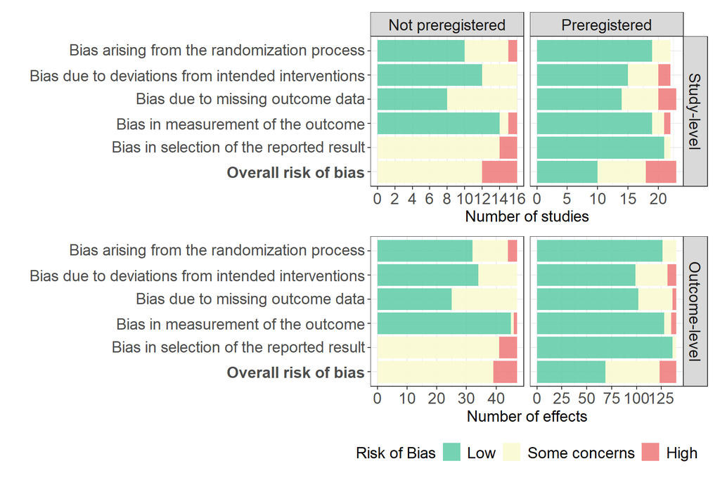

Figure 1: RoB2 plot for reintegration studies and outcomes across type of registration (raw numbers)

```r
rob_pct_studies <-
  rob_sum |>
  mutate(
    Rating = fct_rev(Rating),
    level = "Study-level"
    ) |>
  ggplot(aes(x = studies, y = Category, fill = Rating)) +
  geom_col(alpha = 0.9) +
  facet_grid(level ~ prereg, scales = "free_x") +
  scale_fill_manual(
    values = c("Low" = "mediumaquamarine", "Some concerns" = "lightgoldenrodyellow", "High" = "lightcoral")
  ) +
  scale_y_discrete(
    limits = rev,
    labels = c(
      expression(bold("Overall risk of bias")),
      "Bias in selection of the reported result",
      "Bias in measurement of the outcome",
      "Bias due to missing outcome data",
      "Bias due to deviations from intended interventions",
      "Bias arising from the randomization process"
    )
  ) +
  labs(
    y = "",
    x = "Number of studies",
    fill = "Risk of Bias"
  ) +
  guides(fill = guide_legend(reverse = TRUE)) +
  theme_bw() +
  theme(
    legend.position = "none",
    strip.text.x = element_text(size = 14),
    strip.text.y = element_text(size = 14),
    axis.title = element_text(size = 14),
    axis.text = element_text(size = 14),
    legend.text = element_text(size = 14),
    legend.title = element_text(size = 14)
  )  +
  facetted_pos_scales(
    x = list(
      prereg == "Not preregistered" ~ scale_x_continuous(breaks = seq(0, 16, 2)
      )
    )
  )

rob_pct_effects <-
  rob_sum |>
  mutate(
    Rating = fct_rev(Rating),
    level = "Outcome-level"
    ) |>
  ggplot(aes(x = effects, y = Category, fill = Rating)) +
  geom_col(alpha = 0.9) +
  facet_grid(level ~ prereg, scales = "free_x") +
  scale_fill_manual(
    values = c("Low" = "mediumaquamarine", "Some concerns" = "lightgoldenrodyellow", "High" = "lightcoral")
  ) +
  scale_y_discrete(
    limits = rev,
    labels = c(
      expression(bold("Overall risk of bias")),
      "Bias in selection of the reported result",
      "Bias in measurement of the outcome",
      "Bias due to missing outcome data",
      "Bias due to deviations from intended interventions",
      "Bias arising from the randomization process"
    )
  ) +
  labs(
    x = "Number of effects",
    y = "",
    fill = "Risk of Bias"
  ) +
  guides(fill = guide_legend(reverse = TRUE)) +
  theme_bw() +
  theme(
    legend.position = "bottom",
    strip.text.x = element_blank(),
    strip.text.y = element_text(size = 14),
    axis.title = element_text(size = 14),
    axis.text = element_text(size = 14),
    legend.text = element_text(size = 14),
    legend.title = element_text(size = 14)
  ) +
  facetted_pos_scales(
    x = list(
      prereg == "Preregistered" ~ scale_x_continuous(breaks = seq(0, 150, 25)
      )
    )
  )

#png(filename = "Figures/rob2_reint.png", width = 12, height = 7, units = "in", res = 600)
rob_pct_studies / rob_pct_effects
#dev.off()
```

**Weighted percentage**

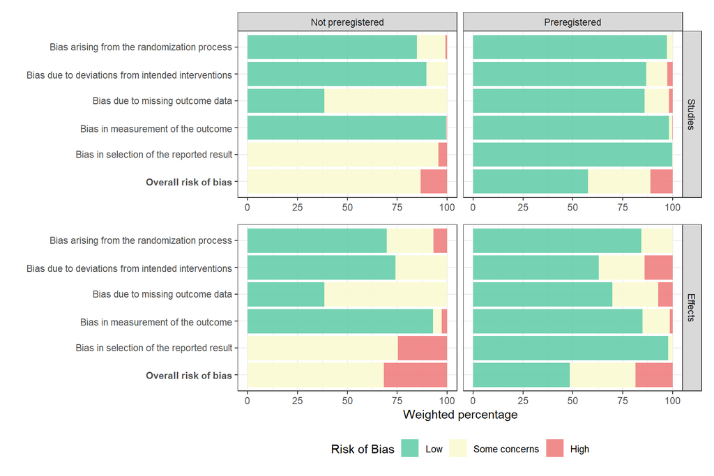

Figure 2: RoB2 plot for reintegration studies and outcomes across type of registration (weighted percentage)

```r
rob_pct_studies_weight <-
  rob_sum |>
  mutate(
    Rating = fct_rev(Rating),
    level = "Studies"
    ) |>
  ggplot(aes(x = studies_pct_w, y = Category, fill = Rating)) +
  geom_col(alpha = 0.9) +
  facet_grid(level ~ prereg, scales = "free_x") +
  scale_fill_manual(
    values = c("Low" = "mediumaquamarine", "Some concerns" = "lightgoldenrodyellow", "High" = "lightcoral")
  ) +
  scale_y_discrete(
    limits = rev,
    labels = c(
      expression(bold("Overall risk of bias")),
      "Bias in selection of the reported result",
      "Bias in measurement of the outcome",
      "Bias due to missing outcome data",
      "Bias due to deviations from intended interventions",
      "Bias arising from the randomization process"
    )
  ) +
  labs(
    y = "",
    fill = "Risk of Bias"
  ) +
  guides(fill = guide_legend(reverse = TRUE)) +
  theme_bw() +
  theme(
    legend.position = "none",
    axis.title.x=element_blank()
  )

rob_pct_effects_weight <-
  rob_sum |>
  mutate(
    Rating = fct_rev(Rating),
    level = "Effects"
    ) |>
  ggplot(aes(x = effects_pct_w, y = Category, fill = Rating)) +
  geom_col(alpha = 0.9) +
  facet_grid(level ~ prereg, scales = "free_x") +
  scale_fill_manual(
    values = c("Low" = "mediumaquamarine", "Some concerns" = "lightgoldenrodyellow", "High" = "lightcoral")
  ) +
  scale_y_discrete(
    limits = rev,
    labels = c(
      expression(bold("Overall risk of bias")),
      "Bias in selection of the reported result",
      "Bias in measurement of the outcome",
      "Bias due to missing outcome data",
      "Bias due to deviations from intended interventions",
      "Bias arising from the randomization process"
    )
  ) +
  labs(
    x = "Weighted percentage",
    y = "",
    fill = "Risk of Bias"
  ) +
  guides(fill = guide_legend(reverse = TRUE)) +
  theme_bw() +
  theme(
    legend.position = "bottom",
    strip.text.x = element_blank()
  )


rob_pct_studies_weight / rob_pct_effects_weight
```

**Raw percentage**

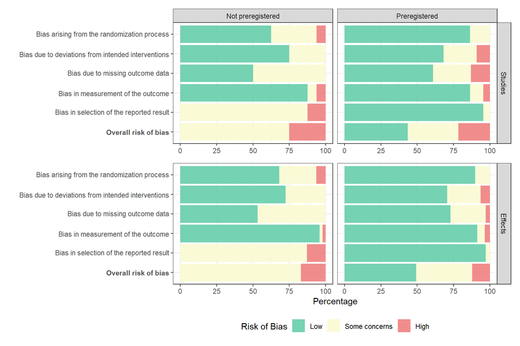

Figure 3: RoB2 plot for reintegration studies and outcomes across type of registration (unweighted percentage)

```r
rob_pct_studies_unweight <-
  rob_sum |>
  mutate(
    Rating = fct_rev(Rating),
    level = "Studies"
    ) |>
  ggplot(aes(x = studies_pct, y = Category, fill = Rating)) +
  geom_col(alpha = 0.9) +
  facet_grid(level ~ prereg, scales = "free_x") +
  scale_fill_manual(
    values = c("Low" = "mediumaquamarine", "Some concerns" = "lightgoldenrodyellow", "High" = "lightcoral")
  ) +
  scale_y_discrete(
    limits = rev,
    labels = c(
      expression(bold("Overall risk of bias")),
      "Bias in selection of the reported result",
      "Bias in measurement of the outcome",
      "Bias due to missing outcome data",
      "Bias due to deviations from intended interventions",
      "Bias arising from the randomization process"
    )
  ) +
  labs(
    y = "",
    fill = "Risk of Bias"
  ) +
  guides(fill = guide_legend(reverse = TRUE)) +
  theme_bw() +
  theme(
    legend.position = "none",
    axis.title.x=element_blank()
  )

rob_pct_effects_unweight <-
  rob_sum |>
  mutate(
    Rating = fct_rev(Rating),
    level = "Effects"
    ) |>
  ggplot(aes(x = effects_pct, y = Category, fill = Rating)) +
  geom_col(alpha = 0.9) +
  facet_grid(level ~ prereg, scales = "free_x") +
  scale_fill_manual(
    values = c("Low" = "mediumaquamarine", "Some concerns" = "lightgoldenrodyellow", "High" = "lightcoral")
  ) +
  scale_y_discrete(
    limits = rev,
    labels = c(
      expression(bold("Overall risk of bias")),
      "Bias in selection of the reported result",
      "Bias in measurement of the outcome",
      "Bias due to missing outcome data",
      "Bias due to deviations from intended interventions",
      "Bias arising from the randomization process"
    )
  ) +
  labs(
    x = "Percentage",
    y = "",
    fill = "Risk of Bias"
  ) +
  guides(fill = guide_legend(reverse = TRUE)) +
  theme_bw() +
  theme(
    legend.position = "bottom",
    strip.text.x = element_blank()
  )


rob_pct_studies_unweight / rob_pct_effects_unweight
```

**Mental health**

**Number of studies/effects**

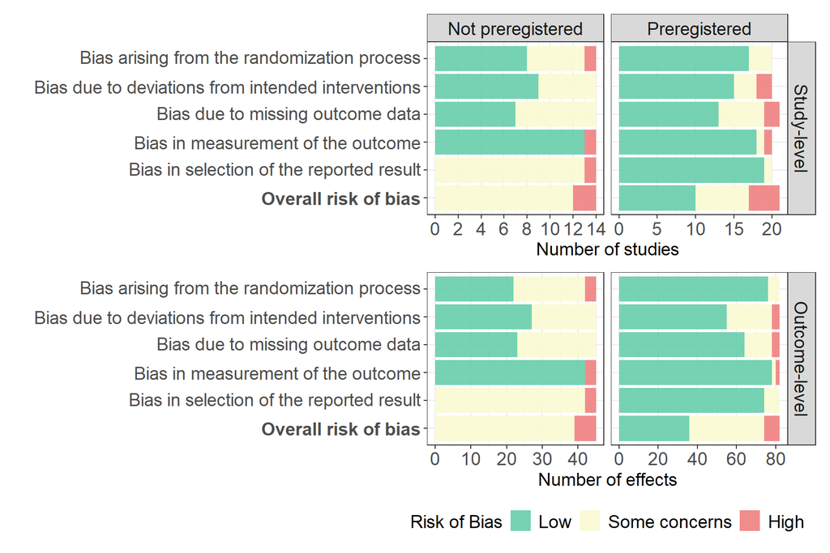

Figure 4: RoB2 plot for mental health studies and outcomes across type of registration (raw numbers)

```r
rob_pct_studies_mental <-
  rob_sum_mental |>
  mutate(
    Rating = fct_rev(Rating),
    level = "Study-level"
    ) |>
  ggplot(aes(x = studies, y = Category, fill = Rating)) +
  geom_col(alpha = 0.9) +
  facet_grid(level ~ prereg, scales = "free_x") +
  scale_fill_manual(
    values = c("Low" = "mediumaquamarine", "Some concerns" = "lightgoldenrodyellow", "High" = "lightcoral")
  ) +
  scale_y_discrete(
    limits = rev,
    labels = c(
      expression(bold("Overall risk of bias")),
      "Bias in selection of the reported result",
      "Bias in measurement of the outcome",
      "Bias due to missing outcome data",
      "Bias due to deviations from intended interventions",
      "Bias arising from the randomization process"
    )
  ) +
  labs(
    y = "",
    x = "Number of studies",
    fill = "Risk of Bias"
  ) +
  guides(fill = guide_legend(reverse = TRUE)) +
  theme_bw() +
  theme(
    legend.position = "none",
    strip.text.x = element_text(size = 14),
    strip.text.y = element_text(size = 14),
    axis.title = element_text(size = 14),
    axis.text = element_text(size = 14),
    legend.text = element_text(size = 14),
    legend.title = element_text(size = 14)
  )  +
  facetted_pos_scales(
    x = list(
      prereg == "Not preregistered" ~ scale_x_continuous(breaks = seq(0, 16, 2)
      )
    )
  )

rob_pct_effects_mental <-
  rob_sum_mental |>
  mutate(
    Rating = fct_rev(Rating),
    level = "Outcome-level"
    ) |>
  ggplot(aes(x = effects, y = Category, fill = Rating)) +
  geom_col(alpha = 0.9) +
  facet_grid(level ~ prereg, scales = "free_x") +
  scale_fill_manual(
    values = c("Low" = "mediumaquamarine", "Some concerns" = "lightgoldenrodyellow", "High" = "lightcoral")
  ) +
  scale_y_discrete(
    limits = rev,
    labels = c(
      expression(bold("Overall risk of bias")),
      "Bias in selection of the reported result",
      "Bias in measurement of the outcome",
      "Bias due to missing outcome data",
      "Bias due to deviations from intended interventions",
      "Bias arising from the randomization process"
    )
  ) +
  labs(
    x = "Number of effects",
    y = "",
    fill = "Risk of Bias"
  ) +
  guides(fill = guide_legend(reverse = TRUE)) +
  theme_bw() +
  theme(
    legend.position = "bottom",
    strip.text.x = element_blank(),
    strip.text.y = element_text(size = 14),
    axis.title = element_text(size = 14),
    axis.text = element_text(size = 14),
    legend.text = element_text(size = 14),
    legend.title = element_text(size = 14)
  )

#png(filename = "Figures/rob2_mental.png", width = 12, height = 7, units = "in", res = 600)
rob_pct_studies_mental / rob_pct_effects_mental
#dev.off()
```

**Weighted percentage**

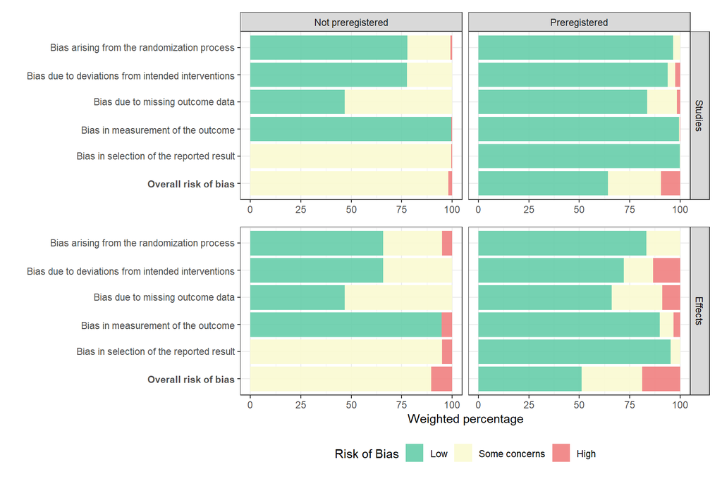

Figure 5: RoB2 plot for mental health studies and outcomes across type of registration (weighted percentage)

```r
rob_pct_studies_weight_mental <-
  rob_sum_mental |>
  mutate(
    Rating = fct_rev(Rating),
    level = "Studies"
    ) |>
  ggplot(aes(x = studies_pct_w, y = Category, fill = Rating)) +
  geom_col(alpha = 0.9) +
  facet_grid(level ~ prereg, scales = "free_x") +
  scale_fill_manual(
    values = c("Low" = "mediumaquamarine", "Some concerns" = "lightgoldenrodyellow", "High" = "lightcoral")
  ) +
  scale_y_discrete(
    limits = rev,
    labels = c(
      expression(bold("Overall risk of bias")),
      "Bias in selection of the reported result",
      "Bias in measurement of the outcome",
      "Bias due to missing outcome data",
      "Bias due to deviations from intended interventions",
      "Bias arising from the randomization process"
    )
  ) +
  labs(
    y = "",
    fill = "Risk of Bias"
  ) +
  guides(fill = guide_legend(reverse = TRUE)) +
  theme_bw() +
  theme(
    legend.position = "none",
    axis.title.x=element_blank()
  )

rob_pct_effects_weight_mental <-
  rob_sum_mental |>
  mutate(
    Rating = fct_rev(Rating),
    level = "Effects"
    ) |>
  ggplot(aes(x = effects_pct_w, y = Category, fill = Rating)) +
  geom_col(alpha = 0.9) +
  facet_grid(level ~ prereg, scales = "free_x") +
  scale_fill_manual(
    values = c("Low" = "mediumaquamarine", "Some concerns" = "lightgoldenrodyellow", "High" = "lightcoral")
  ) +
  scale_y_discrete(
    limits = rev,
    labels = c(
      expression(bold("Overall risk of bias")),
      "Bias in selection of the reported result",
      "Bias in measurement of the outcome",
      "Bias due to missing outcome data",
      "Bias due to deviations from intended interventions",
      "Bias arising from the randomization process"
    )
  ) +
  labs(
    x = "Weighted percentage",
    y = "",
    fill = "Risk of Bias"
  ) +
  guides(fill = guide_legend(reverse = TRUE)) +
  theme_bw() +
  theme(
    legend.position = "bottom",
    strip.text.x = element_blank()
  )


rob_pct_studies_weight_mental / rob_pct_effects_weight_mental
```

**Raw percentage**

[figure not shown]

Figure 6: RoB2 plot for mental health studies and outcomes across type of registration (unweighted percentage)

```r
rob_pct_studies_unweight_mental <-
  rob_sum_mental |>
  mutate(
    Rating = fct_rev(Rating),
    level = "Studies"
    ) |>
  ggplot(aes(x = studies_pct, y = Category, fill = Rating)) +
  geom_col(alpha = 0.9) +
  facet_grid(level ~ prereg, scales = "free_x") +
  scale_fill_manual(
    values = c("Low" = "mediumaquamarine", "Some concerns" = "lightgoldenrodyellow", "High" = "lightcoral")
  ) +
  scale_y_discrete(
    limits = rev,
    labels = c(
      expression(bold("Overall risk of bias")),
      "Bias in selection of the reported result",
      "Bias in measurement of the outcome",
      "Bias due to missing outcome data",
      "Bias due to deviations from intended interventions",
      "Bias arising from the randomization process"
    )
  ) +
  labs(
    y = "",
    fill = "Risk of Bias"
  ) +
  guides(fill = guide_legend(reverse = TRUE)) +
  theme_bw() +
  theme(
    legend.position = "none",
    axis.title.x=element_blank()
  )

rob_pct_effects_unweight <-
  rob_sum_mental |>
  mutate(
    Rating = fct_rev(Rating),
    level = "Effects"
    ) |>
  ggplot(aes(x = effects_pct, y = Category, fill = Rating)) +
  geom_col(alpha = 0.9) +
  facet_grid(level ~ prereg, scales = "free_x") +
  scale_fill_manual(
    values = c("Low" = "mediumaquamarine", "Some concerns" = "lightgoldenrodyellow", "High" = "lightcoral")
  ) +
  scale_y_discrete(
    limits = rev,
    labels = c(
      expression(bold("Overall risk of bias")),
      "Bias in selection of the reported result",
      "Bias in measurement of the outcome",
      "Bias due to missing outcome data",
      "Bias due to deviations from intended interventions",
      "Bias arising from the randomization process"
    )
  ) +
  labs(
    x = "Percentage",
    y = "",
    fill = "Risk of Bias"
  ) +
  guides(fill = guide_legend(reverse = TRUE)) +
  theme_bw() +
  theme(
    legend.position = "bottom",
    strip.text.x = element_blank()
  )


rob_pct_studies_unweight / rob_pct_effects_unweight
```

### Subgrouped risk of bias plots

```r
reint_rob2_subgrp_dat <-
  reintegration_dat |>
  mutate(
    kj = n(),
    sigma2j = mean(vgt_pop),
    weight = 1 / (kj*tau2 + omega2 + (kj-1)*rho*sigma2j + sigma2j),
    .by = study
  ) |>
  filter(rob_tool == "RoB2" & str_detect(analysis_plan, "Alco|Well|Hope|Social")) |>
  select(
    outcome = analysis_plan, prereg = prereg_chr, study, D1:D5, Overall, weight
  ) |>
  mutate(
    outcome = case_match(
      outcome,
      "Alcohol and drug abuse/misuse" ~ "Alcohol/drugs",
      "Hope, empowerment & self-efficacy" ~ "Hope/empower",
      "Social functioning (degree of impairment)" ~ "Social function",
      "Wellbeing and quality of life" ~ "Wellbeing/QoL"
    )
  )


rob_sum_subgrp <-
  reint_rob2_subgrp_dat |>
  pivot_longer(D1:Overall, names_to = "Category", values_to = "Rating") |>
  mutate(
    Category = factor(
      Category, levels = c(paste0("D", 1:5), "Overall"),
      labels = c(
        "Bias arising from the randomization process",
        "Bias due to deviations from intended interventions",
        "Bias due to missing outcome data",
        "Bias in measurement of the outcome",
        "Bias in selection of the reported result",
        "Overall risk of bias"
        )
      ),

    Rating = case_when(str_detect(Rating, "Some") ~ "Some concerns", .default = Rating),

    Rating = factor(Rating, levels = c("Low", "Some concerns", "High"))

  ) |>
  group_by(prereg, outcome, Category, Rating, study) |>
  summarize(
    effects = n(),
    weight = sum(weight),
    .groups = "drop_last"
  ) |>
  summarise(
    studies = length(unique(study)),
    effects = sum(effects),
    weight = sum(weight),
    .groups = "drop_last"
  ) |>
  mutate(
    effects_pct = 100 * effects / sum(effects),
    studies_pct = 100 * studies / sum(studies),
    effects_pct_w = weight/sum(weight) * 100,
    studies_w = studies * weight,
    studies_pct_w = studies_w / sum(studies_w) * 100
  ) |>
  ungroup()

# Mental health
mental_rob2_subgrp_dat <-
  mental_health_dat |>
  mutate(
    kj = n(),
    sigma2j = mean(vgt_pop),
    weight = 1 / (kj*tau2 + omega2 + (kj-1)*rho*sigma2j + sigma2j),
    .by = study
  ) |>
  filter(rob_tool == "RoB2") |>
  select(
    outcome = analysis_plan, prereg = prereg_chr, study, D1:D5, Overall, weight
  ) |>
  mutate(
    outcome = factor(
      outcome,
      levels = c("Anxiety", "Depression", "General mental health", "Symptoms of psychosis")
    )
  )


rob_sum_subgrp_mental <-
  mental_rob2_subgrp_dat |>
  pivot_longer(D1:Overall, names_to = "Category", values_to = "Rating") |>
  mutate(
    Category = factor(
      Category, levels = c(paste0("D", 1:5), "Overall"),
      labels = c(
        "Bias arising from the randomization process",
        "Bias due to deviations from intended interventions",
        "Bias due to missing outcome data",
        "Bias in measurement of the outcome",
        "Bias in selection of the reported result",
        "Overall risk of bias"
        )
      ),

    Rating = case_when(str_detect(Rating, "Some") ~ "Some concerns", .default = Rating),

    Rating = factor(Rating, levels = c("Low", "Some concerns", "High"))

  ) |>
  group_by(prereg, outcome, Category, Rating, study) |>
  summarize(
    effects = n(),
    weight = sum(weight),
    .groups = "drop_last"
  ) |>
  summarise(
    studies = length(unique(study)),
    effects = sum(effects),
    weight = sum(weight),
    .groups = "drop_last"
  ) |>
  mutate(
    effects_pct = 100 * effects / sum(effects),
    studies_pct = 100 * studies / sum(studies),
    effects_pct_w = weight/sum(weight) * 100,
    studies_w = studies * weight,
    studies_pct_w = studies_w / sum(studies_w) * 100
  ) |>
  ungroup()
```

**Reintegration**

**Study-level**

**Number of studies**

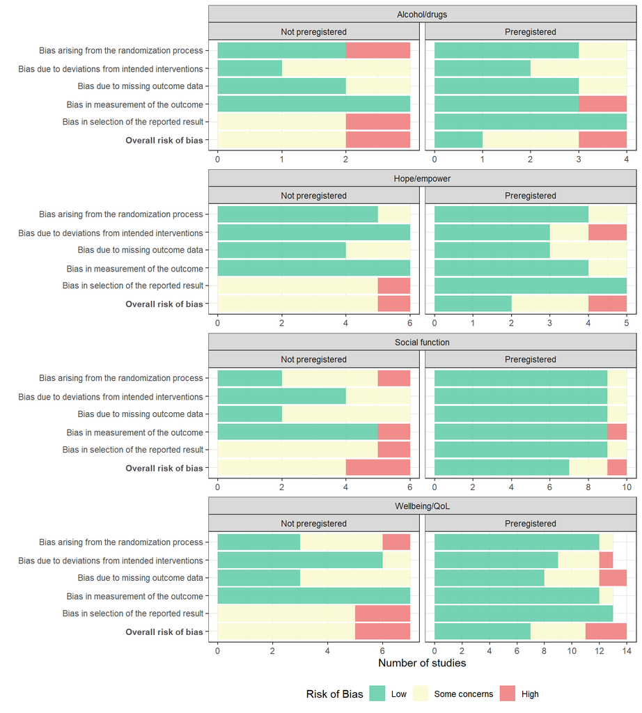

Figure 7: RoB2 plot for reintegration studies and outcomes by type of registration and outcome (number of studies)

```r
rob_studies_subgrp <-
  rob_sum_subgrp |>
  mutate(
    Rating = fct_rev(Rating),
    level = "Studies"
    ) |>
  ggplot(aes(x = studies, y = Category, fill = Rating)) +
  geom_col(alpha = 0.9) +
  facet_nested_wrap(outcome ~ prereg, scales = "free_x", ncol = 2) +
  scale_fill_manual(
    values = c("Low" = "mediumaquamarine", "Some concerns" = "lightgoldenrodyellow", "High" = "lightcoral")
  ) +
  scale_y_discrete(
    limits = rev,
    labels = c(
      expression(bold("Overall risk of bias")),
      "Bias in selection of the reported result",
      "Bias in measurement of the outcome",
      "Bias due to missing outcome data",
      "Bias due to deviations from intended interventions",
      "Bias arising from the randomization process"
    )
  ) +
  labs(
    y = "",
    x = "Number of studies",
    fill = "Risk of Bias"
  ) +
  guides(fill = guide_legend(reverse = TRUE)) +
  theme_bw() +
  theme(
    legend.position = "bottom"
  )  +
  facetted_pos_scales(
    x = list(
      prereg == "Not preregistered" & outcome == "Alcohol/drugs" ~ scale_x_continuous(breaks = seq(0, 2, 1)),
      prereg == "Preregistered" & outcome == "Wellbeing/QoL" ~ scale_x_continuous(breaks = seq(0, 14, 2)),
      prereg == "Preregistered" & outcome == "Social function" ~ scale_x_continuous(breaks = seq(0, 10, 2))
    )
  )

rob_studies_subgrp
```

**Weighted percentage of studies**

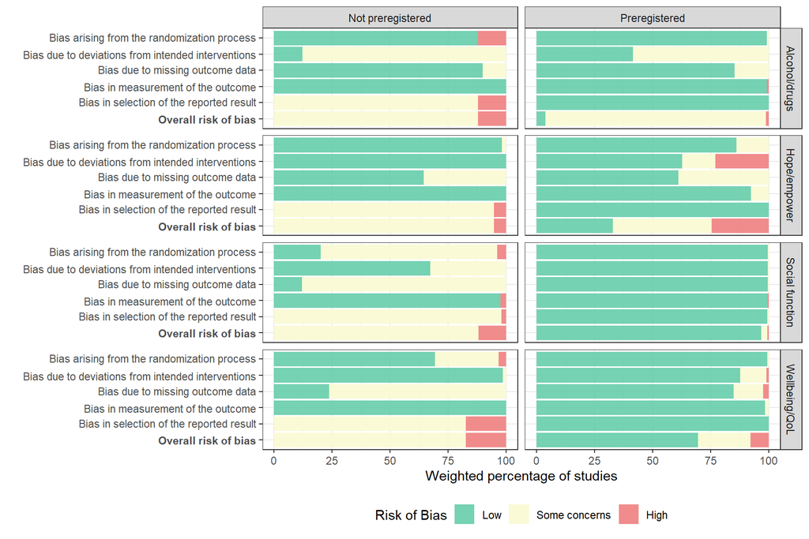

Figure 8: RoB2 plot for reintegration studies and outcomes by type of registration and outcome (weighted percentage of studies)

```r
# Weigthed percent
rob_weight_pct_studies_subgrp <-
  rob_sum_subgrp |>
  mutate(
    Rating = fct_rev(Rating),
    level = "Studies"
    ) |>
  ggplot(aes(x = studies_pct_w, y = Category, fill = Rating)) +
  geom_col(alpha = 0.9) +
  facet_grid2(outcome ~ prereg, scales = "free_x") +
  scale_fill_manual(
    values = c("Low" = "mediumaquamarine", "Some concerns" = "lightgoldenrodyellow", "High" = "lightcoral")
  ) +
  scale_y_discrete(
    limits = rev,
    labels = c(
      expression(bold("Overall risk of bias")),
      "Bias in selection of the reported result",
      "Bias in measurement of the outcome",
      "Bias due to missing outcome data",
      "Bias due to deviations from intended interventions",
      "Bias arising from the randomization process"
    )
  ) +
  labs(
    y = "",
    x = "Weighted percentage of studies",
    fill = "Risk of Bias"
  ) +
  guides(fill = guide_legend(reverse = TRUE)) +
  theme_bw() +
  theme(
    legend.position = "bottom"
  )

rob_weight_pct_studies_subgrp
```

**Unweighted percentage of studies**

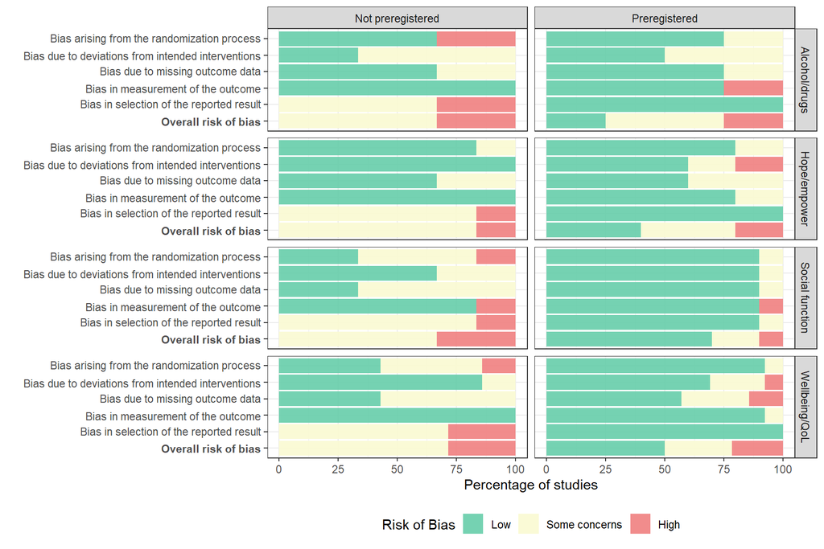

Figure 9: RoB2 plot for reintegration studies and outcomes by type of registration and outcome (unweighted percentage of studies)

```r
# unweigthed percent
rob_unweight_pct_studies_subgrp <-
  rob_sum_subgrp |>
  mutate(
    Rating = fct_rev(Rating),
    level = "Studies"
    ) |>
  ggplot(aes(x = studies_pct, y = Category, fill = Rating)) +
  geom_col(alpha = 0.9) +
  facet_grid2(outcome ~ prereg, scales = "free_x") +
  scale_fill_manual(
    values = c("Low" = "mediumaquamarine", "Some concerns" = "lightgoldenrodyellow", "High" = "lightcoral")
  ) +
  scale_y_discrete(
    limits = rev,
    labels = c(
      expression(bold("Overall risk of bias")),
      "Bias in selection of the reported result",
      "Bias in measurement of the outcome",
      "Bias due to missing outcome data",
      "Bias due to deviations from intended interventions",
      "Bias arising from the randomization process"
    )
  ) +
  labs(
    y = "",
    x = "Percentage of studies",
    fill = "Risk of Bias"
  ) +
  guides(fill = guide_legend(reverse = TRUE)) +
  theme_bw() +
  theme(
    legend.position = "bottom"
  )

rob_unweight_pct_studies_subgrp
```

**Outcome-level**

**Number of effects**

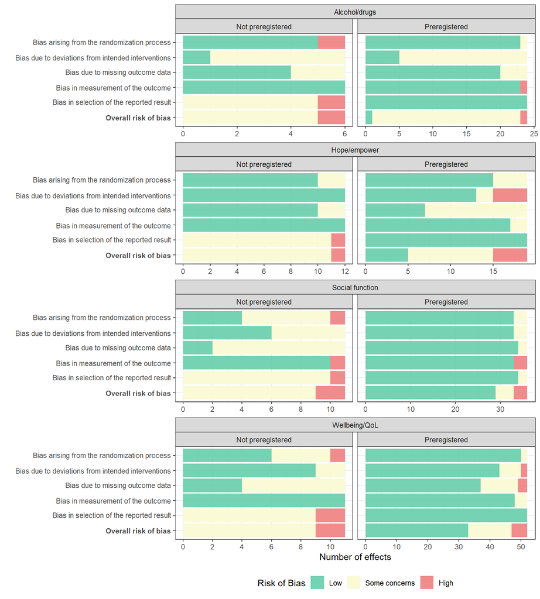

Figure 10: RoB2 plot for reintegration studies and outcomes by type of registration and outcome (number of effects)

```r
rob_effects_subgrp <-
  rob_sum_subgrp |>
  mutate(
    Rating = fct_rev(Rating),
    level = "Effects"
    ) |>
  ggplot(aes(x = effects, y = Category, fill = Rating)) +
  geom_col(alpha = 0.9) +
  facet_nested_wrap(outcome ~ prereg, scales = "free_x", ncol = 2) +
  scale_fill_manual(
    values = c("Low" = "mediumaquamarine", "Some concerns" = "lightgoldenrodyellow", "High" = "lightcoral")
  ) +
  scale_y_discrete(
    limits = rev,
    labels = c(
      expression(bold("Overall risk of bias")),
      "Bias in selection of the reported result",
      "Bias in measurement of the outcome",
      "Bias due to missing outcome data",
      "Bias due to deviations from intended interventions",
      "Bias arising from the randomization process"
    )
  ) +
  labs(
    y = "",
    x = "Number of effects",
    fill = "Risk of Bias"
  ) +
  guides(fill = guide_legend(reverse = TRUE)) +
  theme_bw() +
  theme(
    legend.position = "bottom"
  )  +
  facetted_pos_scales(
    x = list(
      prereg == "Not preregistered" & outcome == "Hope/empower" ~ scale_x_continuous(breaks = seq(0, 12, 2)),
      prereg == "Preregistered" & outcome == "Hope/empower" ~ scale_x_continuous(breaks = seq(0, 20, 5)),
      prereg == "Not preregistered" & outcome == "Social function" ~ scale_x_continuous(breaks = seq(0, 10, 2)),
      prereg == "Preregistered" & outcome == "Social function" ~ scale_x_continuous(breaks = seq(0, 40, 10)),
      prereg == "Not preregistered" & outcome == "Wellbeing/QoL" ~ scale_x_continuous(breaks = seq(0, 10, 2))
    )
  )

rob_effects_subgrp
```

**Weighted percentage of effects**

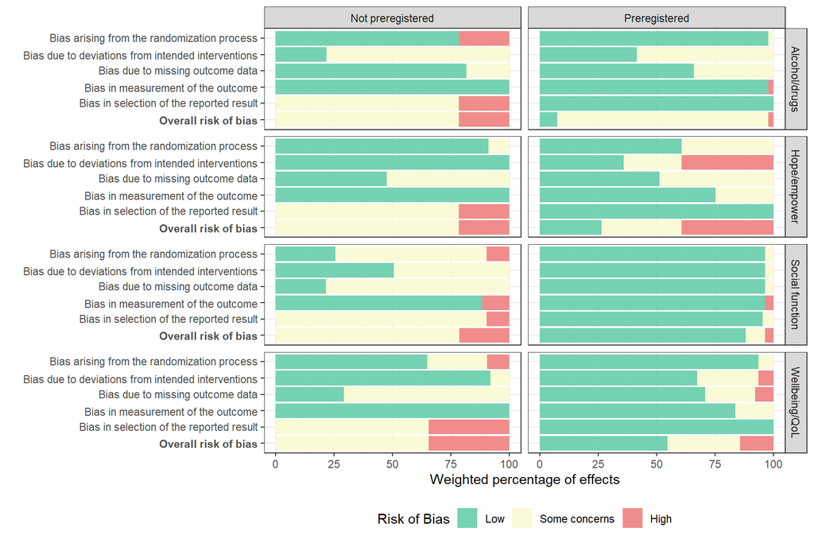

Figure 11: RoB2 plot for reintegration studies and outcomes by type of registration and outcome (weighted percentage of effects)

```r
# Weigthed percent
rob_weight_pct_effects_subgrp <-
  rob_sum_subgrp |>
  mutate(
    Rating = fct_rev(Rating),
    level = "Effects"
    ) |>
  ggplot(aes(x = effects_pct_w, y = Category, fill = Rating)) +
  geom_col(alpha = 0.9) +
  facet_grid2(outcome ~ prereg, scales = "free_x") +
  scale_fill_manual(
    values = c("Low" = "mediumaquamarine", "Some concerns" = "lightgoldenrodyellow", "High" = "lightcoral")
  ) +
  scale_y_discrete(
    limits = rev,
    labels = c(
      expression(bold("Overall risk of bias")),
      "Bias in selection of the reported result",
      "Bias in measurement of the outcome",
      "Bias due to missing outcome data",
      "Bias due to deviations from intended interventions",
      "Bias arising from the randomization process"
    )
  ) +
  labs(
    y = "",
    x = "Weighted percentage of effects",
    fill = "Risk of Bias"
  ) +
  guides(fill = guide_legend(reverse = TRUE)) +
  theme_bw() +
  theme(
    legend.position = "bottom"
  )

rob_weight_pct_effects_subgrp
```

**Unweighted percentage of effects**

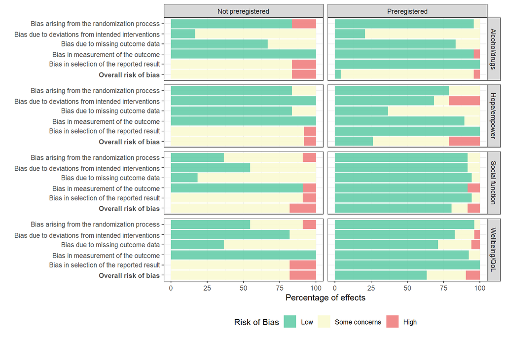

Figure 12: RoB2 plot for reintegration studies and outcomes by type of registration and outcome (unweighted percentage of effects)

```r
# unweigthed percent
rob_unweight_pct_effects_subgrp <-
  rob_sum_subgrp |>
  mutate(
    Rating = fct_rev(Rating),
    level = "Studies"
    ) |>
  ggplot(aes(x = effects_pct, y = Category, fill = Rating)) +
  geom_col(alpha = 0.9) +
  facet_grid2(outcome ~ prereg, scales = "free_x") +
  scale_fill_manual(
    values = c("Low" = "mediumaquamarine", "Some concerns" = "lightgoldenrodyellow", "High" = "lightcoral")
  ) +
  scale_y_discrete(
    limits = rev,
    labels = c(
      expression(bold("Overall risk of bias")),
      "Bias in selection of the reported result",
      "Bias in measurement of the outcome",
      "Bias due to missing outcome data",
      "Bias due to deviations from intended interventions",
      "Bias arising from the randomization process"
    )
  ) +
  labs(
    y = "",
    x = "Percentage of effects",
    fill = "Risk of Bias"
  ) +
  guides(fill = guide_legend(reverse = TRUE)) +
  theme_bw() +
  theme(
    legend.position = "bottom"
  )

rob_unweight_pct_effects_subgrp
```

**Mental health**

**Study-level**

**Number of studies**

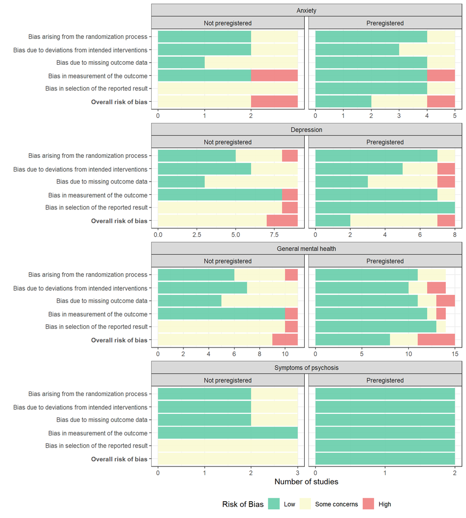

Figure 13: RoB2 plot for mental studies and outcomes by type of registration and outcome (number of studies)

```r
rob_studies_subgrp_mental <-
  rob_sum_subgrp_mental |>
  mutate(
    Rating = fct_rev(Rating),
    level = "Studies"
    ) |>
  ggplot(aes(x = studies, y = Category, fill = Rating)) +
  geom_col(alpha = 0.9) +
  facet_nested_wrap(outcome ~ prereg, scales = "free_x", ncol = 2) +
  scale_fill_manual(
    values = c("Low" = "mediumaquamarine", "Some concerns" = "lightgoldenrodyellow", "High" = "lightcoral")
  ) +
  scale_y_discrete(
    limits = rev,
    labels = c(
      expression(bold("Overall risk of bias")),
      "Bias in selection of the reported result",
      "Bias in measurement of the outcome",
      "Bias due to missing outcome data",
      "Bias due to deviations from intended interventions",
      "Bias arising from the randomization process"
    )
  ) +
  labs(
    y = "",
    x = "Number of studies",
    fill = "Risk of Bias"
  ) +
  guides(fill = guide_legend(reverse = TRUE)) +
  theme_bw() +
  theme(
    legend.position = "bottom"
  )  +
  facetted_pos_scales(
    x = list(
      prereg == "Not preregistered" & outcome == "Anxiety" ~ scale_x_continuous(breaks = seq(0, 2, 1)),
      prereg == "Preregistered" & outcome == "Depression" ~ scale_x_continuous(breaks = seq(0, 10, 2)),
      prereg == "Not preregistered" & outcome == "General mental health" ~ scale_x_continuous(breaks = seq(0, 10, 2)),
      prereg == "Preregistered" & outcome == "Symptoms of psychosis" ~ scale_x_continuous(breaks = seq(0, 2, 1))
    )
  )

rob_studies_subgrp_mental
```

**Weighted percentage of studies**

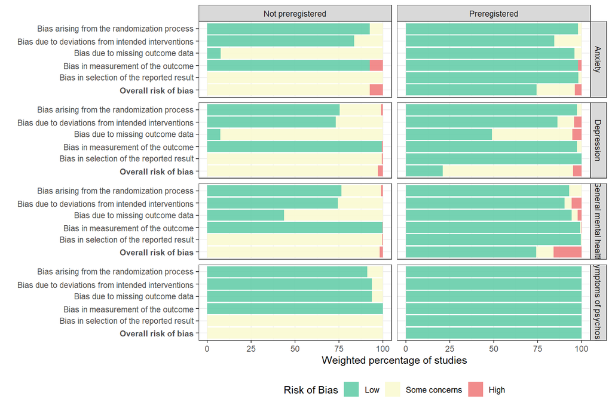

Figure 14: RoB2 plot for mental health studies and outcomes by type of registration and outcome (weighted percentage of studies)

```r
# Weigthed percent
rob_weight_pct_studies_subgrp_mental <-
  rob_sum_subgrp_mental |>
  mutate(
    Rating = fct_rev(Rating),
    level = "Studies"
    ) |>
  ggplot(aes(x = studies_pct_w, y = Category, fill = Rating)) +
  geom_col(alpha = 0.9) +
  facet_grid2(outcome ~ prereg, scales = "free_x") +
  scale_fill_manual(
    values = c("Low" = "mediumaquamarine", "Some concerns" = "lightgoldenrodyellow", "High" = "lightcoral")
  ) +
  scale_y_discrete(
    limits = rev,
    labels = c(
      expression(bold("Overall risk of bias")),
      "Bias in selection of the reported result",
      "Bias in measurement of the outcome",
      "Bias due to missing outcome data",
      "Bias due to deviations from intended interventions",
      "Bias arising from the randomization process"
    )
  ) +
  labs(
    y = "",
    x = "Weighted percentage of studies",
    fill = "Risk of Bias"
  ) +
  guides(fill = guide_legend(reverse = TRUE)) +
  theme_bw() +
  theme(
    legend.position = "bottom"
  )

rob_weight_pct_studies_subgrp_mental
```

**Unweighted percentage of studies**

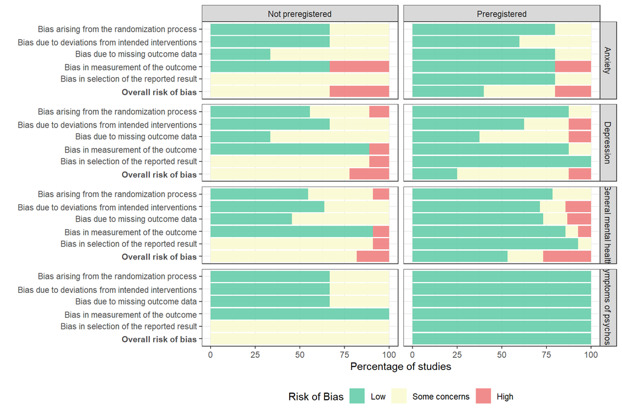

Figure 15: RoB2 plot for mental health studies and outcomes by type of registration and outcome (unweighted percentage of studies)

```r
# unweigthed percent
rob_unweight_pct_studies_subgrp_mental <-
  rob_sum_subgrp_mental |>
  mutate(
    Rating = fct_rev(Rating),
    level = "Studies"
    ) |>
  ggplot(aes(x = studies_pct, y = Category, fill = Rating)) +
  geom_col(alpha = 0.9) +
  facet_grid2(outcome ~ prereg, scales = "free_x") +
  scale_fill_manual(
    values = c("Low" = "mediumaquamarine", "Some concerns" = "lightgoldenrodyellow", "High" = "lightcoral")
  ) +
  scale_y_discrete(
    limits = rev,
    labels = c(
      expression(bold("Overall risk of bias")),
      "Bias in selection of the reported result",
      "Bias in measurement of the outcome",
      "Bias due to missing outcome data",
      "Bias due to deviations from intended interventions",
      "Bias arising from the randomization process"
    )
  ) +
  labs(
    y = "",
    x = "Percentage of studies",
    fill = "Risk of Bias"
  ) +
  guides(fill = guide_legend(reverse = TRUE)) +
  theme_bw() +
  theme(
    legend.position = "bottom"
  )

rob_unweight_pct_studies_subgrp_mental
```

**Outcome-level**

**Number of effects**

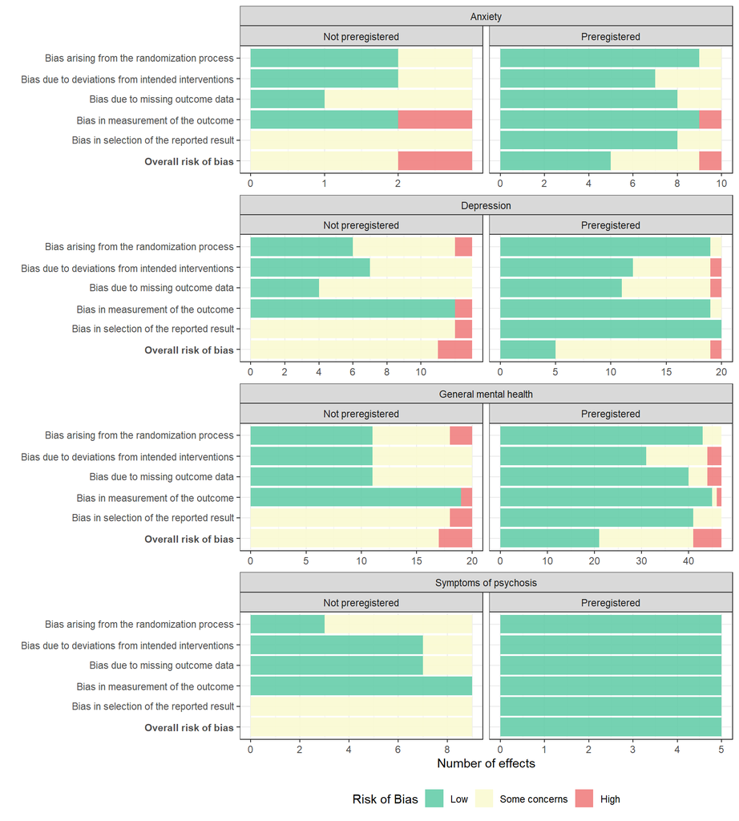

Figure 16: RoB2 plot for mental studies and outcomes by type of registration and outcome (number of effects)

```r
rob_effects_subgrp_mental <-
  rob_sum_subgrp_mental |>
  mutate(
    Rating = fct_rev(Rating),
    level = "Effects"
    ) |>
  ggplot(aes(x = effects, y = Category, fill = Rating)) +
  geom_col(alpha = 0.9) +
  facet_nested_wrap(outcome ~ prereg, scales = "free_x", ncol = 2) +
  scale_fill_manual(
    values = c("Low" = "mediumaquamarine", "Some concerns" = "lightgoldenrodyellow", "High" = "lightcoral")
  ) +
  scale_y_discrete(
    limits = rev,
    labels = c(
      expression(bold("Overall risk of bias")),
      "Bias in selection of the reported result",
      "Bias in measurement of the outcome",
      "Bias due to missing outcome data",
      "Bias due to deviations from intended interventions",
      "Bias arising from the randomization process"
    )
  ) +
  labs(
    y = "",
    x = "Number of effects",
    fill = "Risk of Bias"
  ) +
  guides(fill = guide_legend(reverse = TRUE)) +
  theme_bw() +
  theme(
    legend.position = "bottom"
  )  +
  facetted_pos_scales(
    x = list(
      prereg == "Not preregistered" & outcome == "Anxiety" ~ scale_x_continuous(breaks = seq(0, 2, 1)),
      prereg == "Preregistered" & outcome == "Anxiety" ~ scale_x_continuous(breaks = seq(0, 10, 2)),
      prereg == "Not preregistered" & outcome == "Depression" ~ scale_x_continuous(breaks = seq(0, 10, 2)),
      prereg == "Not preregistered" & outcome == "Symptoms of psychosis" ~ scale_x_continuous(breaks = seq(0, 10, 2))
    )
  )

rob_effects_subgrp_mental
```

**Weighted percentage of effects**

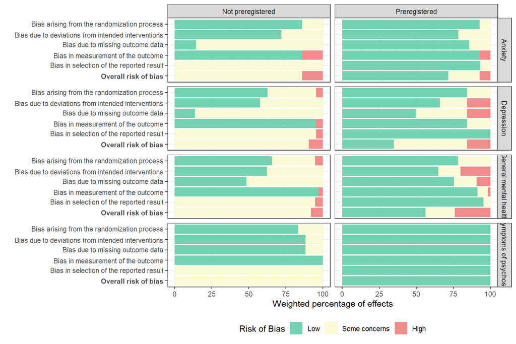

Figure 17: RoB2 plot for mental health studies and outcomes by type of registration and outcome (weighted percentage of effects)

```r
# Weigthed percent
rob_weight_pct_effects_subgrp_mental <-
  rob_sum_subgrp_mental |>
  mutate(
    Rating = fct_rev(Rating),
    level = "Effects"
    ) |>
  ggplot(aes(x = effects_pct_w, y = Category, fill = Rating)) +
  geom_col(alpha = 0.9) +
  facet_grid2(outcome ~ prereg, scales = "free_x") +
  scale_fill_manual(
    values = c("Low" = "mediumaquamarine", "Some concerns" = "lightgoldenrodyellow", "High" = "lightcoral")
  ) +
  scale_y_discrete(
    limits = rev,
    labels = c(
      expression(bold("Overall risk of bias")),
      "Bias in selection of the reported result",
      "Bias in measurement of the outcome",
      "Bias due to missing outcome data",
      "Bias due to deviations from intended interventions",
      "Bias arising from the randomization process"
    )
  ) +
  labs(
    y = "",
    x = "Weighted percentage of effects",
    fill = "Risk of Bias"
  ) +
  guides(fill = guide_legend(reverse = TRUE)) +
  theme_bw() +
  theme(
    legend.position = "bottom"
  )

rob_weight_pct_effects_subgrp_mental
```

**Unweighted percentage of effects**

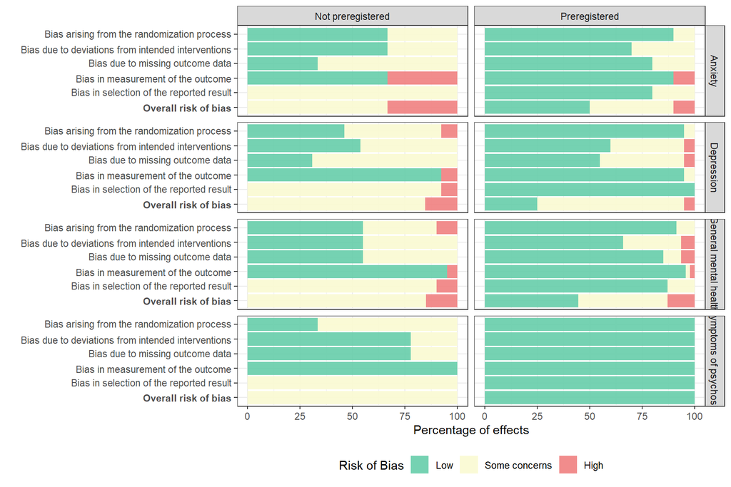

Figure 18: RoB2 plot for mental health studies and outcomes by type of registration and outcome (unweighted percentage of effects)

```r
# unweigthed percent
rob_unweight_pct_effects_subgrp_mental <-
  rob_sum_subgrp_mental |>
  mutate(
    Rating = fct_rev(Rating),
    level = "Studies"
    ) |>
  ggplot(aes(x = effects_pct, y = Category, fill = Rating)) +
  geom_col(alpha = 0.9) +
  facet_grid2(outcome ~ prereg, scales = "free_x") +
  scale_fill_manual(
    values = c("Low" = "mediumaquamarine", "Some concerns" = "lightgoldenrodyellow", "High" = "lightcoral")
  ) +
  scale_y_discrete(
    limits = rev,
    labels = c(
      expression(bold("Overall risk of bias")),
      "Bias in selection of the reported result",
      "Bias in measurement of the outcome",
      "Bias due to missing outcome data",
      "Bias due to deviations from intended interventions",
      "Bias arising from the randomization process"
    )
  ) +
  labs(
    y = "",
    x = "Percentage of effects",
    fill = "Risk of Bias"
  ) +
  guides(fill = guide_legend(reverse = TRUE)) +
  theme_bw() +
  theme(
    legend.position = "bottom"
  )

rob_unweight_pct_effects_subgrp_mental
```

## ROBINS-I

```r
reint_robinsi_dat <-
  reintegration_dat |>
  mutate(
    kj = n(),
    sigma2j = mean(vgt_pop),
    weight = 1 / (kj*tau2 + omega2 + (kj-1)*rho*sigma2j + sigma2j),
    .by = study
  ) |>
  filter(rob_tool == "ROBINS-I") |>
  select(
    prereg = prereg_chr, study, D1:Overall, weight
  )


robinsi_sum <-
  reint_robinsi_dat |>
  pivot_longer(D1:Overall, names_to = "Category", values_to = "Rating") |>
  mutate(
    Category = factor(
      Category, levels = c(paste0("D", 1:7), "Overall"),
      labels = c(
        "Bias due to confounding",
        "Bias due to selection of participants",
        "Bias in classification of interventions",
        "Bias due to deviations from intended interventions",
        "Bias due to missing data",
        "Bias in measurement of outcomes",
        "Bias in selection of the reported result",
        "Overall risk of bias"
        )
      ),

    Rating = factor(Rating, levels = c("Low", "Moderate", "Serious"))

  ) |>
  group_by(Category, Rating, study) |>
  summarize(
    effects = n(),
    weight = sum(weight),
    .groups = "drop_last"
  ) |>
  summarise(
    studies = length(unique(study)),
    effects = sum(effects),
    weight = sum(weight),
    .groups = "drop_last"
  ) |>
  mutate(
    effects_pct = 100 * effects / sum(effects),
    studies_pct = 100 * studies / sum(studies),
    effects_pct_w = weight/sum(weight) * 100,
    studies_w = studies * weight,
    studies_pct_w = studies_w / sum(studies_w) * 100
  ) |>
  ungroup()

# Mental health
mental_robinsi_dat <-
  mental_health_dat |>
  mutate(
    kj = n(),
    sigma2j = mean(vgt_pop),
    weight = 1 / (kj*tau2 + omega2 + (kj-1)*rho*sigma2j + sigma2j),
    .by = study
  ) |>
  filter(rob_tool == "ROBINS-I") |>
  select(
    prereg = prereg_chr, study, D1:Overall, weight
  )


robinsi_sum_mental <-
  mental_robinsi_dat |>
  pivot_longer(D1:Overall, names_to = "Category", values_to = "Rating") |>
  mutate(
    Category = factor(
      Category, levels = c(paste0("D", 1:7), "Overall"),
      labels = c(
        "Bias due to confounding",
        "Bias due to selection of participants",
        "Bias in classification of interventions",
        "Bias due to deviations from intended interventions",
        "Bias due to missing data",
        "Bias in measurement of outcomes",
        "Bias in selection of the reported result",
        "Overall risk of bias"
        )
      ),

    Rating = factor(Rating, levels = c("Low", "Moderate", "Serious"))

  ) |>
  group_by(Category, Rating, study) |>
  summarize(
    effects = n(),
    weight = sum(weight),
    .groups = "drop_last"
  ) |>
  summarise(
    studies = length(unique(study)),
    effects = sum(effects),
    weight = sum(weight),
    .groups = "drop_last"
  ) |>
  mutate(
    effects_pct = 100 * effects / sum(effects),
    studies_pct = 100 * studies / sum(studies),
    effects_pct_w = weight/sum(weight) * 100,
    studies_w = studies * weight,
    studies_pct_w = studies_w / sum(studies_w) * 100
  ) |>
  ungroup()
```

**Reintegration**

**Raw numbers**

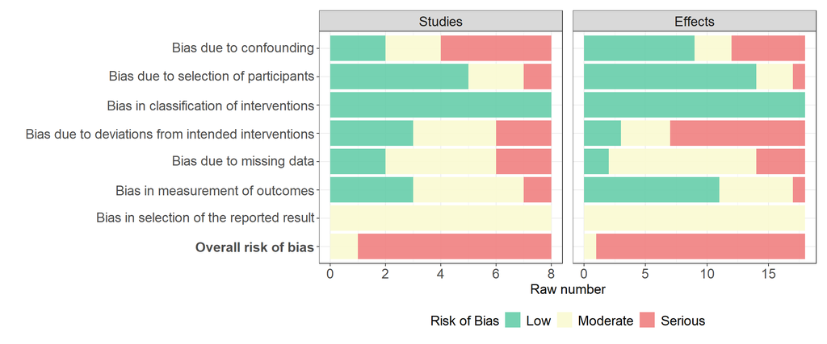

Figure 19: ROBINS-I plot for reintegration QES studies and outcomes (raw number)

```r
robin_studies <-
  robinsi_sum |>
  mutate(
    Rating = fct_rev(Rating),
    level = "Studies"
    ) |>
  ggplot(aes(x = studies, y = Category, fill = Rating)) +
  geom_col(alpha = 0.9) +
  facet_grid(~ level, scales = "free_x") +
  scale_fill_manual(
    values = c("Low" = "mediumaquamarine", "Moderate" = "lightgoldenrodyellow", "Serious" = "lightcoral")
  ) +
  scale_y_discrete(
    limits = rev,
    labels = c(
      expression(bold("Overall risk of bias")),
      "Bias in selection of the reported result",
      "Bias in measurement of outcomes",
      "Bias due to missing data",
      "Bias due to deviations from intended interventions",
      "Bias in classification of interventions",
      "Bias due to selection of participants",
      "Bias due to confounding"
    )
  ) +
  labs(
    y = "",
    x = "Raw number",
    fill = "Risk of Bias"
  ) +
  guides(fill = guide_legend(reverse = TRUE)) +
  theme_bw() +
  theme(
    legend.position = "bottom",
    strip.text.x = element_text(size = 14),
    strip.text.y = element_text(size = 14),
    axis.title = element_text(size = 14),
    axis.text = element_text(size = 14),
    legend.text = element_text(size = 14),
    legend.title = element_text(size = 14)
  )

robin_effects <-
  robinsi_sum  |>
  mutate(
    Rating = fct_rev(Rating),
    level = "Effects"
    ) |>
  ggplot(aes(x = effects, y = Category, fill = Rating)) +
  geom_col(alpha = 0.9) +
  facet_grid(~ level, scales = "free_x") +
  scale_fill_manual(
    values = c("Low" = "mediumaquamarine", "Moderate" = "lightgoldenrodyellow", "Serious" = "lightcoral")
  ) +
  scale_y_discrete(
    limits = rev,
    labels = c(
      expression(bold("Overall risk of bias")),
      "Bias in selection of the reported result",
      "Bias in measurement of outcomes",
      "Bias due to missing data",
      "Bias due to deviations from intended interventions",
      "Bias in classification of interventions",
      "Bias due to selection of participants",
      "Bias due to confounding"
    )
  ) +
  labs(
    y = "",
    x = "Raw number",
    fill = "Risk of Bias"
  ) +
  guides(fill = guide_legend(reverse = TRUE)) +
  theme_bw() +
  theme(
    legend.position = "bottom",
    axis.ticks.y = element_blank(),
    axis.text.y = element_blank(),
    strip.text.x = element_text(size = 14),
    axis.title = element_text(size = 14),
    axis.text = element_text(size = 14),
    legend.text = element_text(size = 14),
    legend.title = element_text(size = 14)
  )


#png(filename = "Figures/ROBINSI_reint.png", width = 12, height = 5, units = "in", res = 600)
(robin_studies + robin_effects) +
  plot_layout(guides = "collect", axis_titles = "collect") & theme(legend.position = 'bottom')
#dev.off()
```

**Weighted percentage**

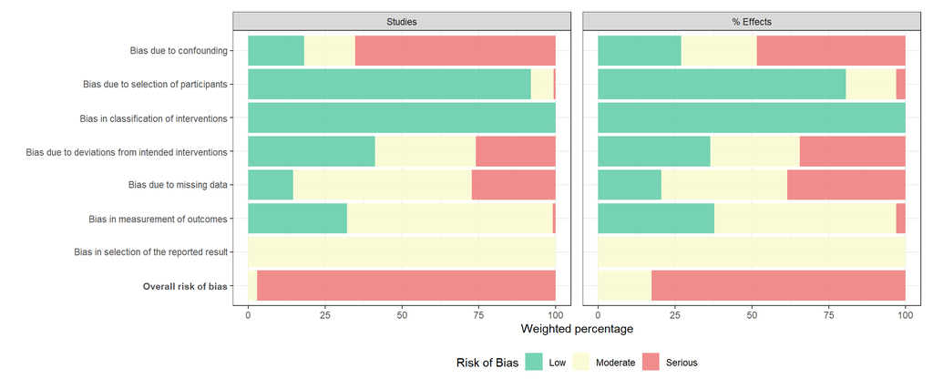

Figure 20: ROBINS-I plot for reintegration QES studies and outcomes (weighted percentage)

```r
robin_pct_studies_weight <-
  robinsi_sum |>
  mutate(
    Rating = fct_rev(Rating),
    level = "Studies"
    ) |>
  ggplot(aes(x = studies_pct_w, y = Category, fill = Rating)) +
  geom_col(alpha = 0.9) +
  facet_grid(~ level, scales = "free_x") +
  scale_fill_manual(
    values = c("Low" = "mediumaquamarine", "Moderate" = "lightgoldenrodyellow", "Serious" = "lightcoral")
  ) +
  scale_y_discrete(
    limits = rev,
    labels = c(
      expression(bold("Overall risk of bias")),
      "Bias in selection of the reported result",
      "Bias in measurement of outcomes",
      "Bias due to missing data",
      "Bias due to deviations from intended interventions",
      "Bias in classification of interventions",
      "Bias due to selection of participants",
      "Bias due to confounding"
    )
  ) +
  labs(
    y = "",
    x = "Weighted percentage",
    fill = "Risk of Bias"
  ) +
  guides(fill = guide_legend(reverse = TRUE)) +
  theme_bw() +
  theme(
    legend.position = "bottom"
  )

robin_pct_effects_weight <-
  robinsi_sum  |>
  mutate(
    Rating = fct_rev(Rating),
    level = "% Effects"
    ) |>
  ggplot(aes(x = effects_pct_w, y = Category, fill = Rating)) +
  geom_col(alpha = 0.9) +
  facet_grid(~ level, scales = "free_x") +
  scale_fill_manual(
    values = c("Low" = "mediumaquamarine", "Moderate" = "lightgoldenrodyellow", "Serious" = "lightcoral")
  ) +
  scale_y_discrete(
    limits = rev,
    labels = c(
      expression(bold("Overall risk of bias")),
      "Bias in selection of the reported result",
      "Bias in measurement of outcomes",
      "Bias due to missing data",
      "Bias due to deviations from intended interventions",
      "Bias in classification of interventions",
      "Bias due to selection of participants",
      "Bias due to confounding"
    )
  ) +
  labs(
    y = "",
    x = "Weighted percentage",
    fill = "Risk of Bias"
  ) +
  guides(fill = guide_legend(reverse = TRUE)) +
  theme_bw() +
  theme(
    legend.position = "bottom",
    axis.ticks.y = element_blank(),
    axis.text.y = element_blank()
  )


(robin_pct_studies_weight + robin_pct_effects_weight) +
  plot_layout(guides = "collect", axis_titles = "collect") & theme(legend.position = 'bottom')
```

**Unweighted percentage**

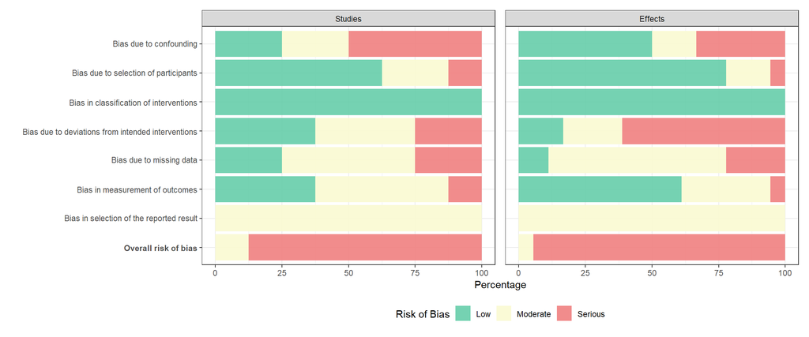

Figure 21: ROBINS-I plot for reintegration QES studies and outcomes (unweighted percentage)

```r
robin_pct_studies_unweight <-
  robinsi_sum |>
  mutate(
    Rating = fct_rev(Rating),
    level = "Studies"
    ) |>
  ggplot(aes(x = studies_pct, y = Category, fill = Rating)) +
  geom_col(alpha = 0.9) +
  facet_grid(~ level, scales = "free_x") +
  scale_fill_manual(
    values = c("Low" = "mediumaquamarine", "Moderate" = "lightgoldenrodyellow", "Serious" = "lightcoral")
  ) +
  scale_y_discrete(
    limits = rev,
    labels = c(
      expression(bold("Overall risk of bias")),
      "Bias in selection of the reported result",
      "Bias in measurement of outcomes",
      "Bias due to missing data",
      "Bias due to deviations from intended interventions",
      "Bias in classification of interventions",
      "Bias due to selection of participants",
      "Bias due to confounding"
    )
  ) +
  labs(
    y = "",
    x = "Percentage",
    fill = "Risk of Bias"
  ) +
  guides(fill = guide_legend(reverse = TRUE)) +
  theme_bw() +
  theme(
    legend.position = "bottom"
  )

robin_pct_effects_unweight <-
  robinsi_sum  |>
  mutate(
    Rating = fct_rev(Rating),
    level = "Effects"
    ) |>
  ggplot(aes(x = effects_pct, y = Category, fill = Rating)) +
  geom_col(alpha = 0.9) +
  facet_grid(~ level, scales = "free_x") +
  scale_fill_manual(
    values = c("Low" = "mediumaquamarine", "Moderate" = "lightgoldenrodyellow", "Serious" = "lightcoral")
  ) +
  scale_y_discrete(
    limits = rev,
    labels = c(
      expression(bold("Overall risk of bias")),
      "Bias in selection of the reported result",
      "Bias in measurement of outcomes",
      "Bias due to missing data",
      "Bias due to deviations from intended interventions",
      "Bias in classification of interventions",
      "Bias due to selection of participants",
      "Bias due to confounding"
    )
  ) +
  labs(
    y = "",
    x = "Percentage",
    fill = "Risk of Bias"
  ) +
  guides(fill = guide_legend(reverse = TRUE)) +
  theme_bw() +
  theme(
    legend.position = "bottom",
    axis.ticks.y = element_blank(),
    axis.text.y = element_blank()
  )




(robin_pct_studies_unweight + robin_pct_effects_unweight) +
  plot_layout(guides = "collect", axis_titles = "collect") & theme(legend.position = 'bottom')
```

**Mental health**

**Raw numbers**

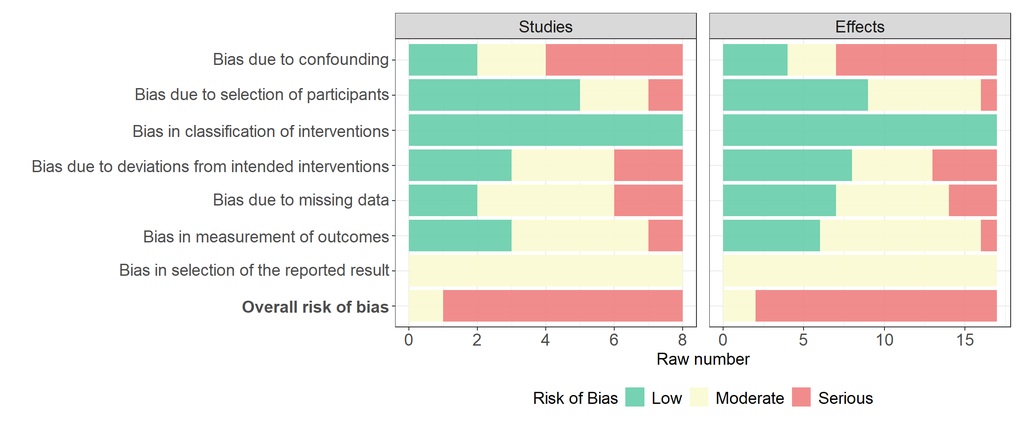

Figure 22: ROBINS-I plot for mental health QES studies and outcomes (raw number)

```r
robin_studies_mental <-
  robinsi_sum_mental |>
  mutate(
    Rating = fct_rev(Rating),
    level = "Studies"
    ) |>
  ggplot(aes(x = studies, y = Category, fill = Rating)) +
  geom_col(alpha = 0.9) +
  facet_grid(~ level, scales = "free_x") +
  scale_fill_manual(
    values = c("Low" = "mediumaquamarine", "Moderate" = "lightgoldenrodyellow", "Serious" = "lightcoral")
  ) +
  scale_y_discrete(
    limits = rev,
    labels = c(
      expression(bold("Overall risk of bias")),
      "Bias in selection of the reported result",
      "Bias in measurement of outcomes",
      "Bias due to missing data",
      "Bias due to deviations from intended interventions",
      "Bias in classification of interventions",
      "Bias due to selection of participants",
      "Bias due to confounding"
    )
  ) +
  labs(
    y = "",
    x = "Raw number",
    fill = "Risk of Bias"
  ) +
  guides(fill = guide_legend(reverse = TRUE)) +
  theme_bw() +
  theme(
    legend.position = "bottom",
    strip.text.y = element_blank(),
    strip.text.x = element_text(size = 14),
    axis.title = element_text(size = 14),
    axis.text = element_text(size = 14),
    legend.text = element_text(size = 14),
    legend.title = element_text(size = 14)
  )

robin_effects_mental <-
  robinsi_sum_mental  |>
  mutate(
    Rating = fct_rev(Rating),
    level = "Effects"
    ) |>
  ggplot(aes(x = effects, y = Category, fill = Rating)) +
  geom_col(alpha = 0.9) +
  facet_grid(~ level, scales = "free_x") +
  scale_fill_manual(
    values = c("Low" = "mediumaquamarine", "Moderate" = "lightgoldenrodyellow", "Serious" = "lightcoral")
  ) +
  scale_y_discrete(
    limits = rev,
    labels = c(
      expression(bold("Overall risk of bias")),
      "Bias in selection of the reported result",
      "Bias in measurement of outcomes",
      "Bias due to missing data",
      "Bias due to deviations from intended interventions",
      "Bias in classification of interventions",
      "Bias due to selection of participants",
      "Bias due to confounding"
    )
  ) +
  labs(
    y = "",
    x = "Raw number",
    fill = "Risk of Bias"
  ) +
  guides(fill = guide_legend(reverse = TRUE)) +
  theme_bw() +
  theme(
    legend.position = "bottom",
    axis.ticks.y = element_blank(),
    axis.text.y = element_blank(),
    strip.text.x = element_text(size = 14),
    axis.title = element_text(size = 14),
    axis.text = element_text(size = 14),
    legend.text = element_text(size = 14),
    legend.title = element_text(size = 14)
  )

#png(filename = "Figures/RONINSI_mental.png", width = 12, height = 5, units = "in", res = 600)
(robin_studies_mental + robin_effects_mental) +
  plot_layout(guides = "collect", axis_titles = "collect") & theme(legend.position = 'bottom')
#dev.off()
```

**Weighted percentage**

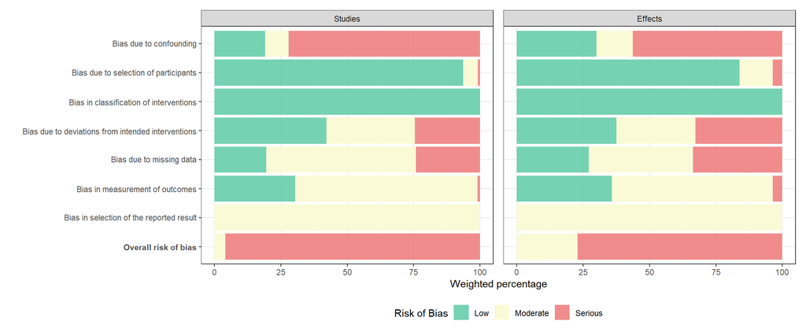

Figure 23: ROBINS-I plot for mental health QES studies and outcomes (weighted percentage)

```r
robin_pct_studies_weight_mental <-
  robinsi_sum_mental |>
  mutate(
    Rating = fct_rev(Rating),
    level = "Studies"
    ) |>
  ggplot(aes(x = studies_pct_w, y = Category, fill = Rating)) +
  geom_col(alpha = 0.9) +
  facet_grid(~ level, scales = "free_x") +
  scale_fill_manual(
    values = c("Low" = "mediumaquamarine", "Moderate" = "lightgoldenrodyellow", "Serious" = "lightcoral")
  ) +
  scale_y_discrete(
    limits = rev,
    labels = c(
      expression(bold("Overall risk of bias")),
      "Bias in selection of the reported result",
      "Bias in measurement of outcomes",
      "Bias due to missing data",
      "Bias due to deviations from intended interventions",
      "Bias in classification of interventions",
      "Bias due to selection of participants",
      "Bias due to confounding"
    )
  ) +
  labs(
    y = "",
    x = "Weighted percentage",
    fill = "Risk of Bias"
  ) +
  guides(fill = guide_legend(reverse = TRUE)) +
  theme_bw() +
  theme(
    legend.position = "bottom"
  )

robin_pct_effects_weight_mental <-
  robinsi_sum_mental  |>
  mutate(
    Rating = fct_rev(Rating),
    level = "Effects"
    ) |>
  ggplot(aes(x = effects_pct_w, y = Category, fill = Rating)) +
  geom_col(alpha = 0.9) +
  facet_grid(~ level, scales = "free_x") +
  scale_fill_manual(
    values = c("Low" = "mediumaquamarine", "Moderate" = "lightgoldenrodyellow", "Serious" = "lightcoral")
  ) +
  scale_y_discrete(
    limits = rev,
    labels = c(
      expression(bold("Overall risk of bias")),
      "Bias in selection of the reported result",
      "Bias in measurement of outcomes",
      "Bias due to missing data",
      "Bias due to deviations from intended interventions",
      "Bias in classification of interventions",
      "Bias due to selection of participants",
      "Bias due to confounding"
    )
  ) +
  labs(
    y = "",
    x = "Weighted percentage",
    fill = "Risk of Bias"
  ) +
  guides(fill = guide_legend(reverse = TRUE)) +
  theme_bw() +
  theme(
    legend.position = "bottom",
    axis.ticks.y = element_blank(),
    axis.text.y = element_blank()
  )


(robin_pct_studies_weight_mental + robin_pct_effects_weight_mental) +
  plot_layout(guides = "collect", axis_titles = "collect") & theme(legend.position = 'bottom')
```

**Unweighted percentage**

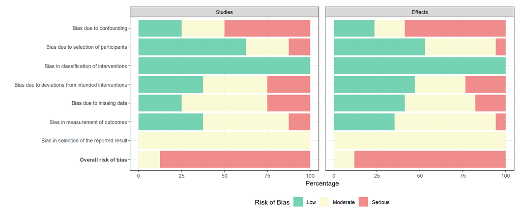

Figure 24: ROBINS-I plot for mental health QES studies and outcomes (unweighted percentage)

```r
robin_pct_studies_unweight_mental <-
  robinsi_sum_mental |>
  mutate(
    Rating = fct_rev(Rating),
    level = "Studies"
    ) |>
  ggplot(aes(x = studies_pct, y = Category, fill = Rating)) +
  geom_col(alpha = 0.9) +
  facet_grid(~ level, scales = "free_x") +
  scale_fill_manual(
    values = c("Low" = "mediumaquamarine", "Moderate" = "lightgoldenrodyellow", "Serious" = "lightcoral")
  ) +
  scale_y_discrete(
    limits = rev,
    labels = c(
      expression(bold("Overall risk of bias")),
      "Bias in selection of the reported result",
      "Bias in measurement of outcomes",
      "Bias due to missing data",
      "Bias due to deviations from intended interventions",
      "Bias in classification of interventions",
      "Bias due to selection of participants",
      "Bias due to confounding"
    )
  ) +
  labs(
    y = "",
    x = "Percentage",
    fill = "Risk of Bias"
  ) +
  guides(fill = guide_legend(reverse = TRUE)) +
  theme_bw() +
  theme(
    legend.position = "bottom"
  )

robin_pct_effects_unweight_mental <-
  robinsi_sum_mental  |>
  mutate(
    Rating = fct_rev(Rating),
    level = "Effects"
    ) |>
  ggplot(aes(x = effects_pct, y = Category, fill = Rating)) +
  geom_col(alpha = 0.9) +
  facet_grid(~ level, scales = "free_x") +
  scale_fill_manual(
    values = c("Low" = "mediumaquamarine", "Moderate" = "lightgoldenrodyellow", "Serious" = "lightcoral")
  ) +
  scale_y_discrete(
    limits = rev,
    labels = c(
      expression(bold("Overall risk of bias")),
      "Bias in selection of the reported result",
      "Bias in measurement of outcomes",
      "Bias due to missing data",
      "Bias due to deviations from intended interventions",
      "Bias in classification of interventions",
      "Bias due to selection of participants",
      "Bias due to confounding"
    )
  ) +
  labs(
    y = "",
    x = "Percentage",
    fill = "Risk of Bias"
  ) +
  guides(fill = guide_legend(reverse = TRUE)) +
  theme_bw() +
  theme(
    legend.position = "bottom",
    axis.ticks.y = element_blank(),
    axis.text.y = element_blank()
  )




(robin_pct_studies_unweight_mental + robin_pct_effects_unweight_mental) +
  plot_layout(guides = "collect", axis_titles = "collect") & theme(legend.position = 'bottom')
```

# Descriptives and Dependence Structures

## Timeline

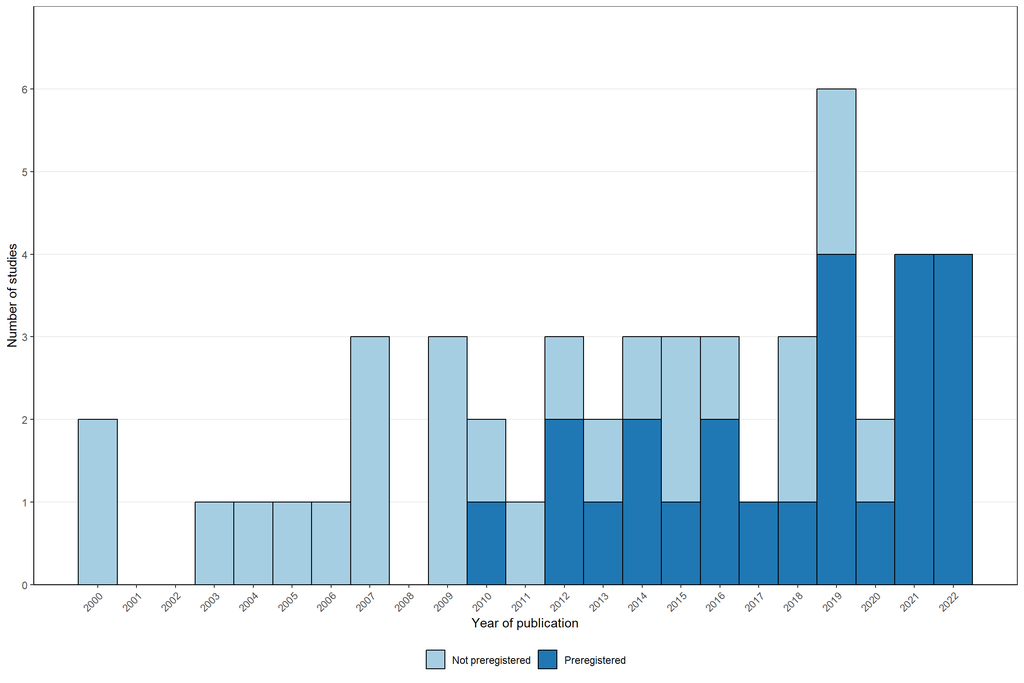

Figure 25: Number of studies included in meta-analysis by year.

```r
# Figure 1: Number of included studies in the meta-analysis by year
G_timeplot <-
  group_based_dat |>
  mutate(
    prereg = if_else(
      str_detect(protocol, regex("yes", ignore_case = TRUE)),
      "Preregistered", "Not preregistered"
    )
  ) |>
  reframe(year = unique(year), prereg = unique(prereg), .by =  study)

# DONE
timeline_plot <-  ggplot(G_timeplot, aes(x = year, fill = prereg)) +
  geom_bar(col = "black", alpha = 1, width = 1) +
  scale_x_continuous(breaks = seq(2000, 2022, 1)) +
  scale_y_continuous(breaks = seq(0, 6.5, 1), limits = c(0, 7), expand = c(0,0)) +
  theme_bw() +
  scale_fill_brewer(palette="Paired")+
  theme(
    axis.text.x = element_text(angle = 45, vjust = 1, hjust = 1),
    #panel.border = element_blank(),
    legend.position = "bottom",
    legend.title = element_blank(),
    panel.grid.minor = element_blank(),
    panel.grid.major.x = element_blank(),
    axis.line = element_line(colour = "black")
  ) +
  labs(
    x = "Year of publication",
    y = "Number of studies",
  )

timeline_plot
```

## Number effects across effect size metrics

```r
# Number of studies reporting OR
group_based_dat |>
  summarise(
    n = n(),
    .by = c(study, effect_size)
  ) |>
  summarise(
    N_studies = length(effect_size),
    N_es = sum(n),
    .by = effect_size
  )
```

[output not shown]

## Average pre-posttest correlation

### Reintegrational outcome

```r
reintegration_dat |>
  filter(
    str_detect(
      ppcor_method, regex("Cal", ignore_case = TRUE),
    ) |
    str_detect(
      ppcor_method, regex("From study", ignore_case = TRUE),
    )
  ) |>
  select(contains("ppcor")) |>
  pull(ppcor) |>
  mean()
```

```
[1] 0.6229602
```

### Mental health

```r
mental_health_dat|>
  filter(
    str_detect(
      ppcor_method, regex("Cal", ignore_case = TRUE),
    ) |
    str_detect(
      ppcor_method, regex("From study", ignore_case = TRUE),
    )
  ) |>
  select(contains("ppcor")) |>
  pull(ppcor) |>
  mean()
```

```
[1] 0.5071045
```

## Number of effect size estimates per study

### Overall per study

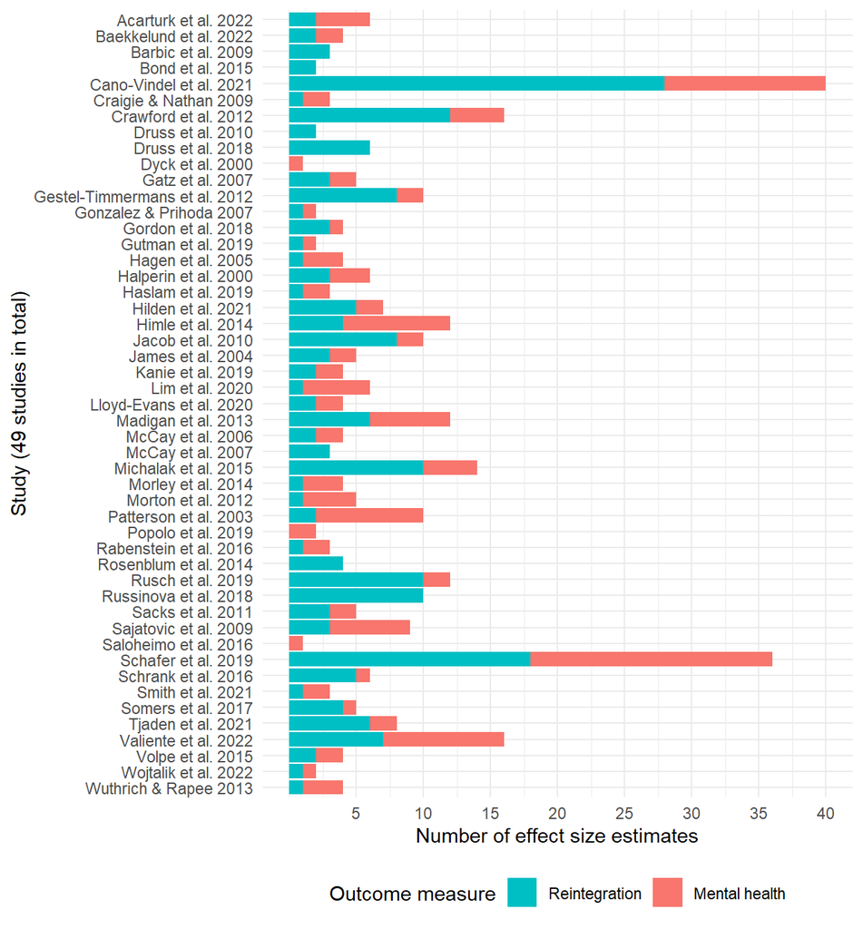

Figure 26: Distribution of number of effect size estimates per study

```r
es_plot_per_study <-
  gb_dat |>
  mutate(
    outcome_label = if_else(str_detect(outcome_construct, "Reint"), "Reintegration", "Mental health")
  ) |>
  arrange(desc(study)) |>
  mutate(study = factor(study, unique(study))) |>
  ggplot(aes(x = study)) +
  geom_bar(aes(fill = outcome_label)) +
  scale_y_continuous(breaks = seq(5, 40, by = 5)) +
  theme_minimal() +
  theme(
    legend.position = "bottom"
  ) +
  coord_flip() +
  labs(
    x = paste0("Study (", n_distinct(gb_dat$study), " studies in total)"),
    y = "Number of effect size estimates",
    fill = "Outcome measure"
  ) +
  guides(fill = guide_legend(reverse=TRUE))

#png(filename = "Figures/Number_es_by_type_of_outcome.png", height = 10, width = 9, res = 600, units = "in")
es_plot_per_study
#dev.off()
```

### Across outcome subgroups per study

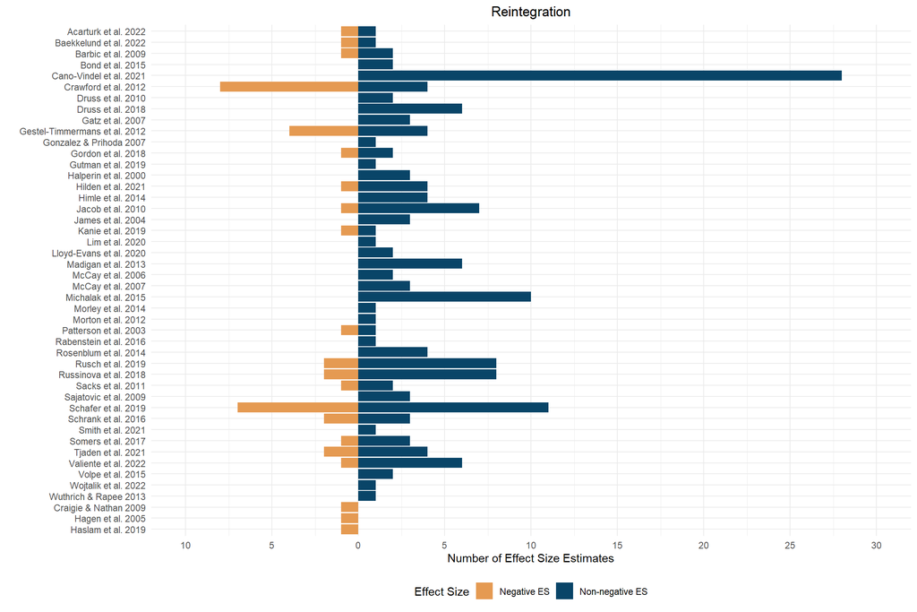

Figure 27: Distribution of number of effects per study, by direction of the effects for reintegrational outcomes.

```r
reintegration_dat |>
ggplot(aes(y = study, fill = gt_pop >= 0)) +
geom_bar(data = subset(reintegration_dat, gt_pop >= 0), aes(x = after_stat(count)), stat = "count") +
geom_bar(data = subset(reintegration_dat, gt_pop < 0), aes(x = -after_stat(count)), stat = "count") +
theme_minimal() +
scale_x_continuous(labels = abs, breaks = scales::breaks_width(5), limits = c(-10, 30)) +
scale_y_discrete(limits=rev) +
scale_fill_manual(
  values = c(met.brewer("Navajo")[2], met.brewer("Navajo")[4]),
  labels = c("Negative ES", "Non-negative ES"),
  name = "Effect Size"
) +
labs(x = "Number of Effect Size Estimates", y = "", title = "Reintegration") +
theme(
    legend.position = "bottom",
    #legend.position.inside = c(0.95, 0.05),
    #legend.justification = c(1, 0),
    legend.background = element_blank(),
    plot.title = element_text(hjust = 0.5)
  )
```

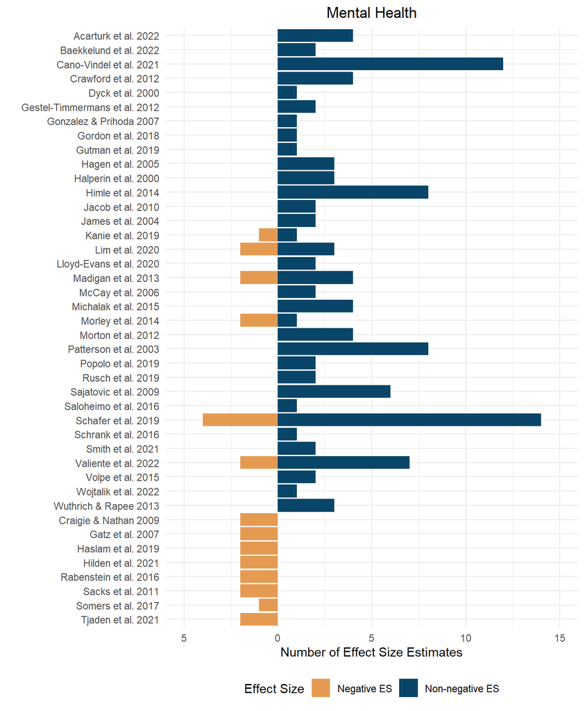

Figure 28: Distribution of number of effects per study, by direction of the effects for mental health outcomes.

```r
mental_health_dat |>
ggplot(aes(y = study, fill = gt_pop >= 0)) +
geom_bar(data = subset(mental_health_dat, gt_pop >= 0), aes(x = after_stat(count)), stat = "count") +
geom_bar(data = subset(mental_health_dat, gt_pop < 0), aes(x = -after_stat(count)), stat = "count") +
theme_minimal() +
scale_x_continuous(labels = abs, breaks = scales::breaks_width(5), limits = c(-5, 15)) +
scale_y_discrete(limits=rev) +
scale_fill_manual(
  values = c(met.brewer("Navajo")[2], met.brewer("Navajo")[4]),
  labels = c("Negative ES", "Non-negative ES"),
  name = "Effect Size"
) +
labs(x = "Number of Effect Size Estimates", y = "", title = "Mental Health") +
theme(
    legend.position = "bottom",
    #legend.position.inside = c(0.95, 0.2),
    #legend.justification = c(1, 0),
    legend.background = element_blank(),
    plot.title = element_text(hjust = 0.5)
  )
```

### Overall across all studies and outcomes

```r
# Multi-arms studies
multi_arm_studies <-
  gb_dat |>
  filter(trt_id > 1) |>
  reframe(study = unique(study))


# Multi-time-points studies
follow_up_studies <-
  gb_dat |>
  summarise(
    time_points = length(unique(time_after_end_intervention_weeks)),
    .by = c(study, trt_id, ctr_id)
  ) |>
  filter(time_points > 1)

# Preregistered studies
prereg_studies <-
  gb_dat |>
  summarise(
    prereg_chr = unique(prereg_chr),
    n_es = n(),
    .by = study
  ) |>
  summarise(
    N_studies = n_distinct(study),
    N_es = sum(n_es),
    .by = prereg_chr
  )

study_sample_sizes <-
  gb_dat |>
  group_by(study, trt_id, ctr_id) |>
  summarise(
    effects = n(),
    participants = max(N_total)
  ) |>
  summarise(
    effects = sum(effects),
    participants = mean(participants),
    ctl_comparisons = n(),
    ctl_arms = paste(ctr_id, collapse = "; ")
  ) |>
  group_by(study, ctl_arms) |>
  summarise(
    effects = sum(effects),
    participants = mean(participants * (1 + ctl_comparisons * (n() - 1) / 2)),
    trt_comparisons = n(),
    trt_arms = paste(trt_id, collapse = "; "),
    ctl_comparisons = mean(ctl_comparisons)
  ) |>
  summarise(
    effects = sum(effects),
    participants = sum(participants),
    trt_comparisons = mean(trt_comparisons),
    ctl_comparisons = sum(ctl_comparisons)
  )

sample_size_summary <-
  study_sample_sizes |>
  summarise(
    studies = n(),
    studies_multiple_tx = sum(trt_comparisons > 1),
    studies_multiple_ctl = sum(ctl_comparisons > 1),
    n_effects = sum(effects),
    mean_effects = mean(effects),
    min_effects = min(effects),
    median_effects = median(effects),
    max_effects = max(effects),
    participants = round(sum(participants))
  ) |>
  mutate(prereg = prereg_studies$N_studies[1])

n_studies <- sample_size_summary$studies
```

```r
kable(
  sample_size_summary,
  col.names = c(
    studies = "Studies",
    studies_multiple_tx = "Multi-treatment studies",
    studies_multiple_ctl = "Multi-control studies",
    n_effects = "Effects",
    mean_effects = "Mean",
    min_effects = "Minimum",
    median_effects = "Median",
    max_effects = "Maximum",
    participants = "Participants",
    prereg = "Preregistered studies"
  ),
  digits = 1
) |>
  kable_styling(bootstrap_options = c("striped", "condensed"),
                full_width = FALSE)
```

Table 3: Data structure for the all data.

[output not shown]

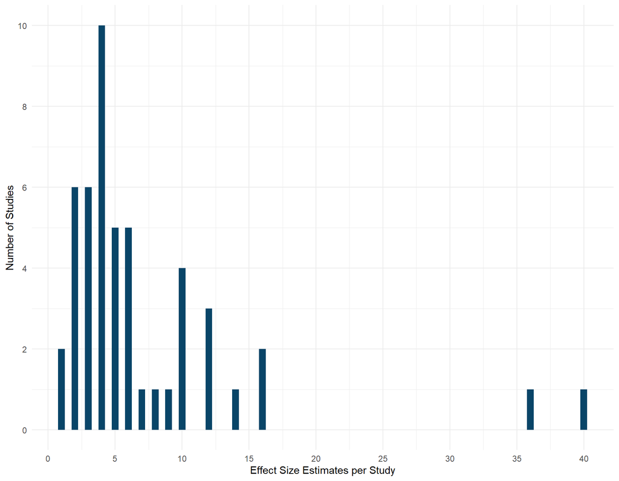

Figure 29: Distribution of number of effect size estimates per study

```r
gb_dat |>
  summarise(
    es_count = n(),
    .by = study
  ) |>
  arrange(es_count) |>
  ggplot(aes(x = es_count)) +
  geom_histogram(binwidth = 0.5, fill = met.brewer("Navajo")[4]) +
  scale_x_continuous(breaks = seq(0, 40, by = 5)) +
  scale_y_continuous(breaks = seq(0, 10, 2)) +
  theme_minimal() +
  labs(x = "Effect Size Estimates per Study", y = "Number of Studies")
```

### Number of effect size estimates per study vs. effect sizes

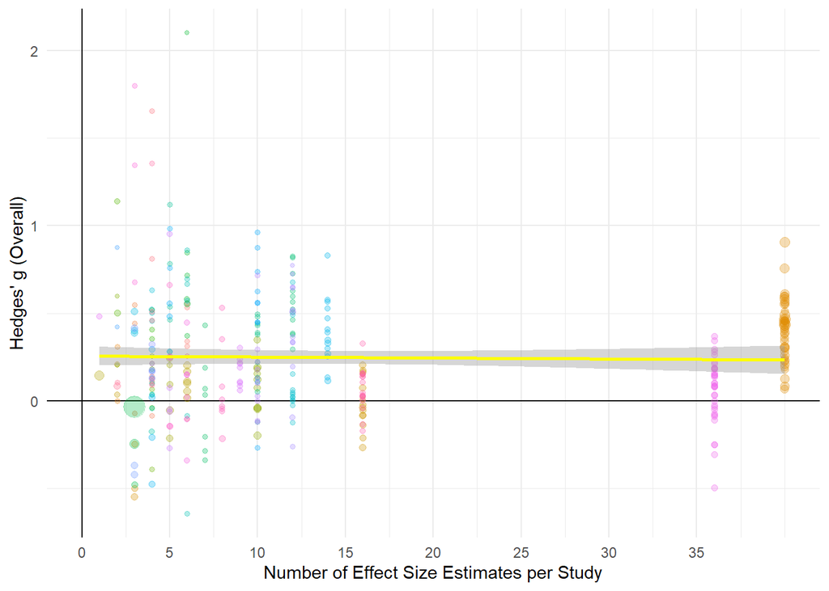

Figure 30: Distribution of number of effects per study vs. effect sizes for overall outcomes.

```r
gb_dat |>
  mutate(
    kj = n(),
    .by = study
  ) |>
  select(study, gt_pop, vgt_pop, kj) |>
  ggplot() +
  aes(x = kj, y = gt_pop, color = study) +
  geom_vline(xintercept = 0) +
  geom_hline(yintercept = 0) +
  geom_point(aes(size = 1/vgt_pop), alpha = 0.30) +
  geom_smooth(method = "lm", formula = y ~ x, color = "yellow") +
  scale_x_continuous(breaks = seq(0, 35, 5)) +
  theme_minimal() +
  theme(legend.position = "none") +
  labs(x = "Number of Effect Size Estimates per Study", y = "Hedges' g (Overall)")
```

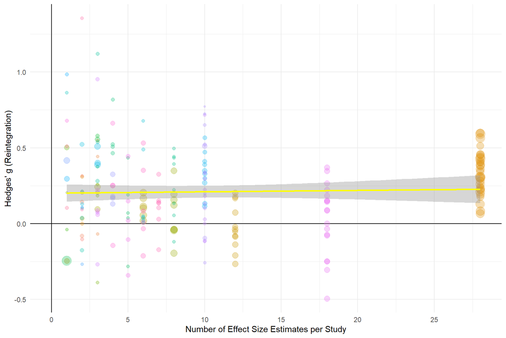

Figure 31: Distribution of number of effects per study vs. effect sizes for reintegrational outcomes.

```r
reintegration_dat |>
  mutate(
    kj = n(),
    .by = study
  ) |>
  select(study, gt_pop, vgt_pop, kj) |>
  ggplot() +
  aes(x = kj, y = gt_pop, color = study) +
  geom_vline(xintercept = 0) +
  geom_hline(yintercept = 0) +
  geom_point(aes(size = 1/vgt_pop), alpha = 0.30) +
  geom_smooth(method = "lm", formula = y ~ x, color = "yellow") +
  scale_x_continuous(breaks = seq(0, 35, 5)) +
  theme_minimal() +
  theme(legend.position = "none") +
  labs(x = "Number of Effect Size Estimates per Study", y = "Hedges' g (Reintegration)")
```

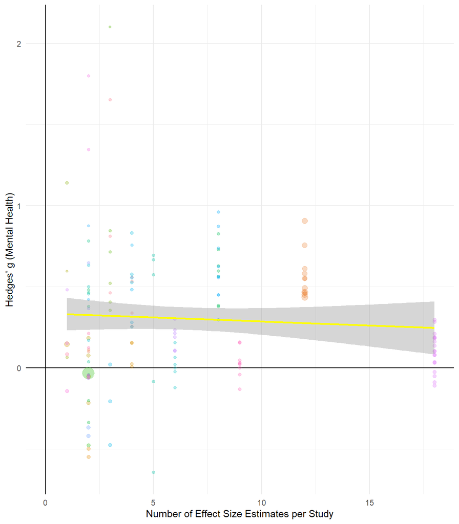

Figure 32: Distribution of number of effects per study vs. effect sizes for mental health outcomes.

```r
mental_health_dat |>
  mutate(
    kj = n(),
    .by = study
  ) |>
  select(study, gt_pop, vgt_pop, kj) |>
  ggplot() +
  aes(x = kj, y = gt_pop, color = study) +
  geom_vline(xintercept = 0) +
  geom_hline(yintercept = 0) +
  geom_point(aes(size = 1/vgt_pop), alpha = 0.30) +
  geom_smooth(method = "lm", formula = y ~ x, color = "yellow") +
  scale_x_continuous(breaks = seq(0, 25, 5)) +
  theme_minimal() +
  theme(legend.position = "none") +
  labs(x = "Number of Effect Size Estimates per Study", y = "Hedges' g (Mental Health)")
```